# I Contexte

Cette analyse préexploratoire des données de la Banque mondiale https://datacatalog.worldbank.org/dataset/education-statistics se place dans un contexte de projet d'expension à l'international d'academy.

Objectifs de l'étude :

- Quels sont les pays avec un fort potentiel de clients pour nos services ?
- Pour chacun de ces pays, quelle sera l’évolution de ce potentiel de clients ?
- Dans quels pays l'entreprise doit-elle opérer en priorité ?

Axes explorés pour répondre à ces questions :

- accès internet et qualité du réseau afin de pouvoir diffuser du contenu en ligne
- population lycéen et étudiants importante
- pouvoir d'achat élevé des cibles
- finalité cours en ligne:
  - soutien à ceux qui sonts déja en formation
  - formation complémentaire

## Import des librairies utilisées

```python
#Import des librairies nécessaires
import pandas as pd
# import re
import numpy as np
import matplotlib.pyplot as plt
import seaborn as sns
import missingno as msno
import scipy.stats as st
import operator
from matplotlib.ticker import EngFormatter,PercentFormatter
from scipy.stats import zscore

sns.set_style("whitegrid")

from pandas_profiling import ProfileReport
```

# II Analyse descriptive des données mises à disposition

Liste des fichiers fournis :

- EdStatsCountry.csv
- EdStatsCountry-Series.csv
- EdStatsData.csv
- EdStatsFootNote.csv
- EdStatsSeries.csv

## Affichage d'un DataFrame suivi d'une synthèse de chaque colonne (type, non nuls, dupliqués et taux de remplissage)

```python
#Fonction affichant un  DataFrame suivi d'une synthèse de chaque colonne (type, non nuls, dupliqués et taux de remplissage)
def Sumary (Data):
    # nombre de lignes du tableau
    lignes=Data.shape[0]
    # nombre de colonnes du tableau
    colonnes=Data.shape[1]
    # taux de rempisage global du tableau
    remp=round((Data.notna().sum()/lignes/colonnes*100).sum(),0)
    # vignette affichage caractéristiques
    plt.figure(figsize=(2,1))
    # pas de grille, pas d'axex
    plt.grid(b=False)
    plt.axis('off')
    # affichage du texte
    plt.text(.3,.3,'Table composée de :\n '+str(lignes)+' lignes x '
             +str(colonnes)+' colonnes \n\nComplètée à '+str(remp)+'%',fontsize=20)
    print('Echantillon')
    # affichage échantillon de 3 lignes
    display(Data.sample(3))
    # affichage infos
    display(Data.info())
    #Création du DataFrame contenant les infos de la table
    sumary=pd.DataFrame(index=['Type','Non null','Uniques','Remplissage '])
    for col in Data.columns:
        #ajout d'une colone au sommaire contenant les infos relatives à la colonne de même nom du dataframe Data
        sumary[col]=[Data[col].dtype,
                      Data[col].count(),
                      len(Data[col].unique()),
                      str(Data[col].count()/Data.shape[0]*100)+' %']
    print('\nSUMMARY ',file)
    # affichage sommaire
    display(sumary)
    del(sumary)
```

## Contenu du fichier EdStatsCountry.csv

```python
# nom du fichier 'EdStatsCountry.csv'
file='EdStatsCountry.csv'
print('Données contenues dans',file)
#Chargement du contenu du fichier dans un DataFrame
Data = pd.read_csv('../Données/'+file)
# appel de la fonction sommaire
Sumary(Data)
```

```
Données contenues dans EdStatsCountry.csv
Echantillon
```

|  | Country Code | Short Name | Table Name | Long Name | 2-alpha code | Currency Unit | Special Notes | Region | Income Group | WB-2 code | ... | IMF data dissemination standard | Latest population census | Latest household survey | Source of most recent Income and expenditure data | Vital registration complete | Latest agricultural census | Latest industrial data | Latest trade data | Latest water withdrawal data | Unnamed: 31 |
| --- | --- | --- | --- | --- | --- | --- | --- | --- | --- | --- | --- | --- | --- | --- | --- | --- | --- | --- | --- | --- | --- |
| 178 | PRK | Dem. People's Rep. Korea | Korea, Dem. Rep. | Democratic People's Republic of Korea | KP | Democratic People's Republic of Korean won | NaN | East Asia & Pacific | Low income | KP | ... | NaN | 2008 | Multiple Indicator Cluster Survey (MICS), 2009 | NaN | NaN | NaN | NaN | NaN | 2005 | NaN |
| 221 | TUV | Tuvalu | Tuvalu | Tuvalu | TV | Australian dollar | Based on data from the IMF, World Bank and gov... | East Asia & Pacific | Upper middle income | TV | ... | General Data Dissemination System (GDDS) | 2012 | NaN | 2013 national accounts estimates are based on ... | NaN | NaN | NaN | 2008.0 | NaN | NaN |
| 2 | AGO | Angola | Angola | People's Republic of Angola | AO | Angolan kwanza | April 2013 database update: Based on IMF data,... | Sub-Saharan Africa | Upper middle income | AO | ... | General Data Dissemination System (GDDS) | 1970 | Malaria Indicator Survey (MIS), 2011 | Integrated household survey (IHS), 2008 | NaN | 2015 | NaN | NaN | 2005 | NaN |

3 rows × 32 columns

```
<class 'pandas.core.frame.DataFrame'>
RangeIndex: 241 entries, 0 to 240
Data columns (total 32 columns):
 #   Column                                             Non-Null Count  Dtype
---  ------                                             --------------  -----
 0   Country Code                                       241 non-null    object
 1   Short Name                                         241 non-null    object
 2   Table Name                                         241 non-null    object
 3   Long Name                                          241 non-null    object
 4   2-alpha code                                       238 non-null    object
 5   Currency Unit                                      215 non-null    object
 6   Special Notes                                      145 non-null    object
 7   Region                                             214 non-null    object
 8   Income Group                                       214 non-null    object
 9   WB-2 code                                          240 non-null    object
```

[output cut: 24 more lines]

```
None
```

```
SUMMARY  EdStatsCountry.csv
```

|  | Country Code | Short Name | Table Name | Long Name | 2-alpha code | Currency Unit | Special Notes | Region | Income Group | WB-2 code | ... | IMF data dissemination standard | Latest population census | Latest household survey | Source of most recent Income and expenditure data | Vital registration complete | Latest agricultural census | Latest industrial data | Latest trade data | Latest water withdrawal data | Unnamed: 31 |
| --- | --- | --- | --- | --- | --- | --- | --- | --- | --- | --- | --- | --- | --- | --- | --- | --- | --- | --- | --- | --- | --- |
| Type | object | object | object | object | object | object | object | object | object | object | ... | object | object | object | object | object | object | float64 | float64 | object | float64 |
| Non null | 241 | 241 | 241 | 241 | 238 | 215 | 145 | 214 | 214 | 240 | ... | 181 | 213 | 141 | 160 | 111 | 142 | 107 | 185 | 179 | 0 |
| Uniques | 241 | 241 | 241 | 241 | 239 | 153 | 132 | 8 | 6 | 241 | ... | 3 | 28 | 61 | 76 | 3 | 36 | 12 | 14 | 21 | 1 |
| Remplissage | 100.0 % | 100.0 % | 100.0 % | 100.0 % | 98.7551867219917 % | 89.21161825726142 % | 60.16597510373444 % | 88.79668049792531 % | 88.79668049792531 % | 99.5850622406639 % | ... | 75.10373443983403 % | 88.38174273858921 % | 58.50622406639005 % | 66.39004149377593 % | 46.058091286307054 % | 58.921161825726145 % | 44.398340248962654 % | 76.76348547717843 % | 74.27385892116183 % | 0.0 % |

4 rows × 32 columns

Le jeu de données EdStatsCountry.csv contient des indications géographiques (région) et macro économiques (income group) de 241 pays. Il va permettre de créer un dictionnaire des pays de chaque régions

## Création du dictionnaire des pays

```python
Data = pd.read_csv('../Données/EdStatsCountry.csv')
#Création de la table liant les pays aux régions
Dic_Pays_Regions=pd.DataFrame({'Country Name':Data['Table Name'], 'Region':Data['Region']})
display(Dic_Pays_Regions)
```

|  | Country Name | Region |
| --- | --- | --- |
| 0 | Aruba | Latin America & Caribbean |
| 1 | Afghanistan | South Asia |
| 2 | Angola | Sub-Saharan Africa |
| 3 | Albania | Europe & Central Asia |
| 4 | Andorra | Europe & Central Asia |
| ... | ... | ... |
| 236 | Kosovo | Europe & Central Asia |
| 237 | Yemen, Rep. | Middle East & North Africa |
| 238 | South Africa | Sub-Saharan Africa |
| 239 | Zambia | Sub-Saharan Africa |
| 240 | Zimbabwe | Sub-Saharan Africa |

241 rows × 2 columns

## Contenu du fichier EdStatsCountry-Series.csv

```python
#Fichier 'EdStatsCountry-Series.csv'   2
file='EdStatsCountry-Series.csv'
print('Données contenues dans',file)
#Chargement du contenu du fichier dans un DataFrame
Data = pd.read_csv('../Données/'+file)
# affichage du sommaire
Sumary(Data)
```

```
Données contenues dans EdStatsCountry-Series.csv
Echantillon
```

|  | CountryCode | SeriesCode | DESCRIPTION | Unnamed: 3 |
| --- | --- | --- | --- | --- |
| 8 | AFG | NY.GDP.PCAP.PP.KD | Estimates are based on regression. | NaN |
| 316 | MAR | SP.POP.1564.TO.ZS | Morocco only. (Excluding former Spanish Sahara) | NaN |
| 535 | TKM | NY.GDP.PCAP.PP.KD | Estimates are based on regression. | NaN |

```
<class 'pandas.core.frame.DataFrame'>
RangeIndex: 613 entries, 0 to 612
Data columns (total 4 columns):
 #   Column       Non-Null Count  Dtype
---  ------       --------------  -----
 0   CountryCode  613 non-null    object
 1   SeriesCode   613 non-null    object
 2   DESCRIPTION  613 non-null    object
 3   Unnamed: 3   0 non-null      float64
dtypes: float64(1), object(3)
memory usage: 19.3+ KB
```

```
None
```

```
SUMMARY  EdStatsCountry-Series.csv
```

|  | CountryCode | SeriesCode | DESCRIPTION | Unnamed: 3 |
| --- | --- | --- | --- | --- |
| Type | object | object | object | float64 |
| Non null | 613 | 613 | 613 | 0 |
| Uniques | 211 | 21 | 97 | 1 |
| Remplissage | 100.0 % | 100.0 % | 100.0 % | 0.0 % |

Le jeu de données EdStatsCountry-Series.csv décrit la source des indices ou leur mode de constitution.

## Contenu du fichier EdStatsSeries.csv

```python
#Fichier 'EdStatsSeries.csv' 3
file='EdStatsSeries.csv'
print('Données contenues dans',file)
#Chargement du contenu du fichier dans un DataFrame
Data = pd.read_csv('../Données/'+file)
# affichage du sommaire
Sumary(Data)
```

```
Données contenues dans EdStatsSeries.csv
Echantillon
```

|  | Series Code | Topic | Indicator Name | Short definition | Long definition | Unit of measure | Periodicity | Base Period | Other notes | Aggregation method | ... | Notes from original source | General comments | Source | Statistical concept and methodology | Development relevance | Related source links | Other web links | Related indicators | License Type | Unnamed: 20 |
| --- | --- | --- | --- | --- | --- | --- | --- | --- | --- | --- | --- | --- | --- | --- | --- | --- | --- | --- | --- | --- | --- |
| 3025 | UIS.GGR.5.A.GPI | Tertiary | Gross graduation ratio from first degree progr... | NaN | Ratio of female gross graduation ratio to the ... | NaN | NaN | NaN | NaN | NaN | ... | NaN | NaN | UNESCO Institute for Statistics | NaN | NaN | NaN | NaN | NaN | NaN | NaN |
| 3355 | UIS.REPP.2.GPV.G4.F | Secondary | Percentage of repeaters in Grade 4 of lower se... | NaN | Total number of pupils in the specified grade ... | NaN | NaN | NaN | NaN | NaN | ... | NaN | NaN | UNESCO Institute for Statistics | NaN | NaN | NaN | NaN | NaN | NaN | NaN |
| 2155 | SABER.TECH.GOAL2.LVL1 | Teachers (SABER) | SABER: (Teachers) Policy Goal 2 Lever 1: Are e... | Data Interpretation: 1=Latent; 2=Emerging; 3=E... | Data Interpretation: 1=Latent; 2=Emerging; 3=E... | NaN | NaN | NaN | NaN | NaN | ... | NaN | NaN | Systems Approach for Better Education Results ... | NaN | NaN | http://saber.worldbank.org/index.cfm | NaN | NaN | NaN | NaN |

3 rows × 21 columns

```
<class 'pandas.core.frame.DataFrame'>
RangeIndex: 3665 entries, 0 to 3664
Data columns (total 21 columns):
 #   Column                               Non-Null Count  Dtype
---  ------                               --------------  -----
 0   Series Code                          3665 non-null   object
 1   Topic                                3665 non-null   object
 2   Indicator Name                       3665 non-null   object
 3   Short definition                     2156 non-null   object
 4   Long definition                      3665 non-null   object
 5   Unit of measure                      0 non-null      float64
 6   Periodicity                          99 non-null     object
 7   Base Period                          314 non-null    object
 8   Other notes                          552 non-null    object
 9   Aggregation method                   47 non-null     object
 10  Limitations and exceptions           14 non-null     object
 11  Notes from original source           0 non-null      float64
 12  General comments                     14 non-null     object
 13  Source                               3665 non-null   object
 14  Statistical concept and methodology  23 non-null     object
 15  Development relevance                3 non-null      object
 16  Related source links                 215 non-null    object
 17  Other web links                      0 non-null      float64
 18  Related indicators                   0 non-null      float64
 19  License Type                         0 non-null      float64
 20  Unnamed: 20                          0 non-null      float64
dtypes: float64(6), object(15)
memory usage: 601.4+ KB
```

```
None
```

```
SUMMARY  EdStatsSeries.csv
```

|  | Series Code | Topic | Indicator Name | Short definition | Long definition | Unit of measure | Periodicity | Base Period | Other notes | Aggregation method | ... | Notes from original source | General comments | Source | Statistical concept and methodology | Development relevance | Related source links | Other web links | Related indicators | License Type | Unnamed: 20 |
| --- | --- | --- | --- | --- | --- | --- | --- | --- | --- | --- | --- | --- | --- | --- | --- | --- | --- | --- | --- | --- | --- |
| Type | object | object | object | object | object | float64 | object | object | object | object | ... | float64 | object | object | object | object | object | float64 | float64 | float64 | float64 |
| Non null | 3665 | 3665 | 3665 | 2156 | 3665 | 0 | 99 | 314 | 552 | 47 | ... | 0 | 14 | 3665 | 23 | 3 | 215 | 0 | 0 | 0 | 0 |
| Uniques | 3665 | 37 | 3665 | 1170 | 2060 | 1 | 2 | 5 | 15 | 4 | ... | 1 | 9 | 31 | 3 | 2 | 2 | 1 | 1 | 1 | 1 |
| Remplissage | 100.0 % | 100.0 % | 100.0 % | 58.82673942701228 % | 100.0 % | 0.0 % | 2.7012278308321966 % | 8.567530695770804 % | 15.061391541609822 % | 1.2824010914051842 % | ... | 0.0 % | 0.3819918144611187 % | 100.0 % | 0.6275579809004093 % | 0.08185538881309685 % | 5.866302864938609 % | 0.0 % | 0.0 % | 0.0 % | 0.0 % |

4 rows × 21 columns

Le jeu de données est un dictionnaire des indicateurs. Il permt donc faire une préselection des indicateurs pouvant répondre aux objectifs de l'étude.

## Contenu du fichier EdStatsFootNote.csv

```
Données contenues dans EdStatsFootNote.csv
Echantillon
```

|  | CountryCode | SeriesCode | Year | DESCRIPTION | Unnamed: 4 |
| --- | --- | --- | --- | --- | --- |
| 505053 | QAT | SE.SEC.ENRL.VO | YR2007 | Country estimation. | NaN |
| 518175 | SAU | SE.TER.GRAD.ED.FE.ZS | YR2000 | Estimated | NaN |
| 44531 | BEN | SE.TER.ENRR | YR1997 | Country Data | NaN |

```
<class 'pandas.core.frame.DataFrame'>
RangeIndex: 643638 entries, 0 to 643637
Data columns (total 5 columns):
 #   Column       Non-Null Count   Dtype
---  ------       --------------   -----
 0   CountryCode  643638 non-null  object
 1   SeriesCode   643638 non-null  object
 2   Year         643638 non-null  object
 3   DESCRIPTION  643638 non-null  object
 4   Unnamed: 4   0 non-null       float64
dtypes: float64(1), object(4)
memory usage: 24.6+ MB
```

```
None
```

```
SUMMARY  EdStatsFootNote.csv
```

|  | CountryCode | SeriesCode | Year | DESCRIPTION | Unnamed: 4 |
| --- | --- | --- | --- | --- | --- |
| Type | object | object | object | object | float64 |
| Non null | 643638 | 643638 | 643638 | 643638 | 0 |
| Uniques | 239 | 1558 | 56 | 9102 | 1 |
| Remplissage | 100.0 % | 100.0 % | 100.0 % | 100.0 % | 0.0 % |

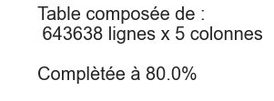

```python
#Fichier 'EdStatsFootNote.csv' 4
file='EdStatsFootNote.csv'
print('Données contenues dans',file)
#Chargement du contenu du fichier dans un DataFrame
Data = pd.read_csv('../Données/'+file)
# affichage du sommaire
Sumary(Data)
```

Ce fichier contient la date de dernier renseignement et la source de chaque indicateur par pays.

## Contenu du fichier EdStatsData.csv

```
Données contenues dans  EdStatsData.csv
Echantillon
```

|  | Country Name | Country Code | Indicator Name | Indicator Code | 1970 | 1971 | 1972 | 1973 | 1974 | 1975 | ... | 2060 | 2065 | 2070 | 2075 | 2080 | 2085 | 2090 | 2095 | 2100 | Unnamed: 69 |
| --- | --- | --- | --- | --- | --- | --- | --- | --- | --- | --- | --- | --- | --- | --- | --- | --- | --- | --- | --- | --- | --- |
| 122032 | Armenia | ARM | EGRA: Reading Comprehension - Share of student... | LO.EGRA.READ.0.FLF.2GRD | NaN | NaN | NaN | NaN | NaN | NaN | ... | NaN | NaN | NaN | NaN | NaN | NaN | NaN | NaN | NaN | NaN |
| 719456 | Sint Maarten (Dutch part) | SXM | Elderly illiterate population, 65+ years, male... | UIS.LP.AG65.M | NaN | NaN | NaN | NaN | NaN | NaN | ... | NaN | NaN | NaN | NaN | NaN | NaN | NaN | NaN | NaN | NaN |
| 675123 | Romania | ROU | EGRA: Correct Letter Names Read Per Minute (Me... | LO.EGRA.CLPM.TIG.2GRD | NaN | NaN | NaN | NaN | NaN | NaN | ... | NaN | NaN | NaN | NaN | NaN | NaN | NaN | NaN | NaN | NaN |

3 rows × 70 columns

```
<class 'pandas.core.frame.DataFrame'>
RangeIndex: 886930 entries, 0 to 886929
Data columns (total 70 columns):
 #   Column          Non-Null Count   Dtype
---  ------          --------------   -----
 0   Country Name    886930 non-null  object
 1   Country Code    886930 non-null  object
 2   Indicator Name  886930 non-null  object
 3   Indicator Code  886930 non-null  object
 4   1970            72288 non-null   float64
 5   1971            35537 non-null   float64
 6   1972            35619 non-null   float64
 7   1973            35545 non-null   float64
 8   1974            35730 non-null   float64
 9   1975            87306 non-null   float64
```

[output cut: 62 more lines]

```
None
```

```
SUMMARY  EdStatsData.csv
```

|  | Country Name | Country Code | Indicator Name | Indicator Code | 1970 | 1971 | 1972 | 1973 | 1974 | 1975 | ... | 2060 | 2065 | 2070 | 2075 | 2080 | 2085 | 2090 | 2095 | 2100 | Unnamed: 69 |
| --- | --- | --- | --- | --- | --- | --- | --- | --- | --- | --- | --- | --- | --- | --- | --- | --- | --- | --- | --- | --- | --- |
| Type | object | object | object | object | float64 | float64 | float64 | float64 | float64 | float64 | ... | float64 | float64 | float64 | float64 | float64 | float64 | float64 | float64 | float64 | float64 |
| Non null | 886930 | 886930 | 886930 | 886930 | 72288 | 35537 | 35619 | 35545 | 35730 | 87306 | ... | 51436 | 51436 | 51436 | 51436 | 51436 | 51436 | 51436 | 51436 | 51436 | 0 |
| Uniques | 242 | 242 | 3665 | 3665 | 24596 | 30893 | 30983 | 30989 | 31140 | 37839 | ... | 7915 | 7801 | 7701 | 7563 | 7467 | 7336 | 7151 | 7045 | 6915 | 1 |
| Remplissage | 100.0 % | 100.0 % | 100.0 % | 100.0 % | 8.150361358844552 % | 4.006742358472484 % | 4.015987732966525 % | 4.007644346228 % | 4.028502813074312 % | 9.843617872887375 % | ... | 5.799330274091529 % | 5.799330274091529 % | 5.799330274091529 % | 5.799330274091529 % | 5.799330274091529 % | 5.799330274091529 % | 5.799330274091529 % | 5.799330274091529 % | 5.799330274091529 % | 0.0 % |

4 rows × 70 columns

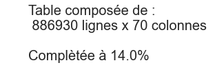

```python
#Fichier 'EdStatsData.csv' 5
file='EdStatsData.csv'
print('Données contenues dans ',file)
#Chargement du contenu du fichier dans un DataFrame
Data = pd.read_csv('../Données/'+file)
# affichage du sommaire
Sumary(Data)
```

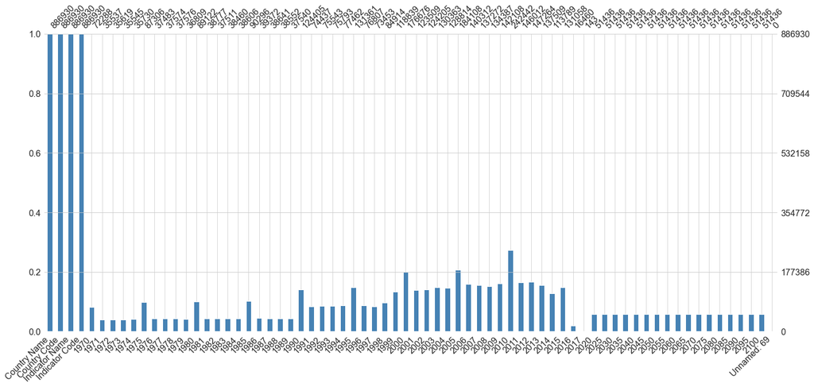

```python
# affichage des valeurs manquantes
msno.bar(Data,labels=True,color='steelblue')
```

# III Choix des indicateurs

## Selection des indicateurs par topic

Regardons plus en détails le jeu de données du fichier EdStatsSeries.csv

```python
#Chargement du jeu de données dans le DataFrame
Data = pd.read_csv("../Données/EdStatsSeries.csv")
print('Taille du tableau : ',Data.shape[0],' lignes x ',Data.shape[1],' colones ')
```

```
Taille du tableau :  3665  lignes x  21  colones
```

Taux de remplissage des colonnes

```python
display(Data.count()/Data.shape[0])
```

[output not shown]

Suppression de la colonne Unamed qui est vide

```python
Data=Data.dropna(how='all',axis=1)
```

Affichage des différents Topics

```python
Data['Topic'].unique()
```

```
array(['Attainment', 'Education Equality',
       'Infrastructure: Communications', 'Learning Outcomes',
       'Economic Policy & Debt: National accounts: US$ at current prices: Aggregate indicators',
       'Economic Policy & Debt: National accounts: US$ at constant 2010 prices: Aggregate indicators',
       'Economic Policy & Debt: Purchasing power parity',
       'Economic Policy & Debt: National accounts: Atlas GNI & GNI per capita',
       'Teachers', 'Education Management Information Systems (SABER)',
       'Early Child Development (SABER)',
       'Engaging the Private Sector (SABER)',
       'School Health and School Feeding (SABER)',
       'School Autonomy and Accountability (SABER)',
       'School Finance (SABER)', 'Student Assessment (SABER)',
       'Teachers (SABER)', 'Tertiary Education (SABER)',
       'Workforce Development (SABER)', 'Literacy', 'Background',
       'Primary', 'Secondary', 'Tertiary', 'Early Childhood Education',
       'Pre-Primary', 'Expenditures', 'Health: Risk factors',
       'Health: Mortality',
       'Social Protection & Labor: Labor force structure', 'Laber',
       'Social Protection & Labor: Unemployment',
       'Health: Population: Structure', 'Population',
       'Health: Population: Dynamics', 'EMIS',
       'Post-Secondary/Non-Tertiary'], dtype=object)
```

Création d'une liste contenant les index des indicateurs retenus

```python
# initialisation à vide de la liste qui contiendra les index des indicateurs retenus
IndRetenus=[]
```

```python
# topic Attainment
mask=Data['Topic']=='Attainment'
with pd.option_context('max_colwidth',0,'max_rows',999):
    display(Data[mask]['Indicator Name'])
```

```
0       Barro-Lee: Percentage of female population age 15-19 with no education
1       Barro-Lee: Percentage of population age 15-19 with no education
2       Barro-Lee: Percentage of female population age 15+ with no education
3       Barro-Lee: Percentage of population age 15+ with no education
4       Barro-Lee: Percentage of female population age 20-24 with no education
5       Barro-Lee: Percentage of population age 20-24 with no education
6       Barro-Lee: Percentage of female population age 25-29 with no education
7       Barro-Lee: Percentage of population age 25-29 with no education
8       Barro-Lee: Percentage of female population age 25+ with no education
9       Barro-Lee: Percentage of population age 25+ with no education
10      Barro-Lee: Percentage of female population age 30-34 with no education
11      Barro-Lee: Percentage of population age 30-34 with no education
12      Barro-Lee: Percentage of female population age 35-39 with no education
13      Barro-Lee: Percentage of population age 35-39 with no education
14      Barro-Lee: Percentage of female population age 40-44 with no education
```

[output cut: 719 more lines]

Indicateurs retenus :

30 Barro-Lee: Population in thousands, age 15-19, total

34 Barro-Lee: Population in thousands, age 20-24, total

36 Barro-Lee: Population in thousands, age 25-29, total

181 Barro-Lee: Percentage of population age 15-19 with secondary schooling. Completed Secondary

185 Barro-Lee: Percentage of population age 20-24 with secondary schooling. Completed Secondary

187 Barro-Lee: Percentage of population age 25-29 with secondary schooling. Completed Secondary

```python
# ajout des index à la liste
IndRetenus.extend([30,34,36,181,185,187])
```

```python
# topic
mask=Data['Topic']=='Education Equality'
with pd.option_context('max_colwidth',0,'max_rows',999):
    display(Data[mask]['Indicator Name'])
```

```
360     DHS: Gross attendance rate. Post Secondary
361     DHS: Gross attendance rate. Post Secondary. Female
362     DHS: Gross attendance rate. Post Secondary. Male
363     DHS: Gross attendance rate. Post Secondary. Quintile 1
364     DHS: Gross attendance rate. Post Secondary. Quintile 2
365     DHS: Gross attendance rate. Post Secondary. Quintile 3
366     DHS: Gross attendance rate. Post Secondary. Quintile 4
367     DHS: Gross attendance rate. Post Secondary. Quintile 5
368     DHS: Gross attendance rate. Post Secondary. Rural
369     DHS: Gross attendance rate. Post Secondary. Urban
370     DHS: Net attendance rate. Primary
371     DHS: Net attendance rate. Primary. Female
372     DHS: Net attendance rate. Primary. Male
373     DHS: Net attendance rate. Primary. Quintile 1
374     DHS: Net attendance rate. Primary. Quintile 2
```

[output cut: 412 more lines]

Aucun indicateur retenu dans cette liste.

```python
# topic Infrastructure: Communications
mask=Data['Topic']=='Infrastructure: Communications'
with pd.option_context('max_colwidth', 0):
    display(Data[mask]['Indicator Name'])
```

```
610    Personal computers (per 100 people)
611    Internet users (per 100 people)
Name: Indicator Name, dtype: object
```

Indicateurs retenus :

610 Personal computers (per 100 people)

611 Internet users (per 100 people)

```python
# ajout des index à la liste
IndRetenus.extend([610,611])
```

```python
# topic Economic Policy & Debt: Purchasing power parity
mask=Data['Topic']=='Economic Policy & Debt: Purchasing power parity'
with pd.option_context('max_colwidth', 0):
    display(Data[mask]['Indicator Name'])
```

```
1660    GDP, PPP (current international $)
1661    GDP, PPP (constant 2011 international $)
1664    GDP per capita, PPP (current international $)
1665    GDP per capita, PPP (constant 2011 international $)
1667    GNI, PPP (current international $)
1669    GNI per capita, PPP (current international $)
Name: Indicator Name, dtype: object
```

Indicateurs retenus :

1660 GDP, PPP (current international $)

1664 GDP per capita, PPP (current international $)

```python
# ajout des index à la liste
IndRetenus.extend([1660,1664])
```

```python
# topic Secondary
mask=Data['Topic']=='Secondary'
with pd.option_context('max_colwidth',0,'max_rows',999):
    display(Data[mask]['Indicator Name'])
```

```
2218    Gross enrolment ratio, primary and secondary, gender parity index (GPI)
2219    Gross enrolment ratio, secondary, gender parity index (GPI)
2287    Official entrance age to lower secondary education (years)
2288    Lower secondary completion rate, female (%)
2289    Lower secondary completion rate, male (%)
2290    Lower secondary completion rate, both sexes (%)
2291    Theoretical duration of secondary education (years)
2292    Theoretical duration of lower secondary education (years)
2293    Theoretical duration of upper secondary education (years)
2294    Enrolment in secondary education, both sexes (number)
2295    Enrolment in secondary education, female (number)
2296    Percentage of female students in secondary education enrolled in vocational programmes, female (%)
2297    Percentage of students in secondary education who are female (%)
2298    Enrolment in secondary general, both sexes (number)
2299    Enrolment in secondary general, female (number)
```

[output cut: 242 more lines]

```python
# topic Tertiary
mask=Data['Topic']=='Tertiary'
with pd.option_context('max_colwidth', 0,'max_rows',999):
    display(Data[mask]['Indicator Name'])
```

```
2220    Gross enrolment ratio, tertiary, gender parity index (GPI)
2284    School life expectancy, primary to tertiary, both sexes (years)
2285    School life expectancy, primary to tertiary, female (years)
2286    School life expectancy, primary to tertiary, male (years)
2329    Gross graduation ratio from first degree programmes (ISCED 6 and 7) in tertiary education, female (%)
2330    Gross graduation ratio from first degree programmes (ISCED 6 and 7) in tertiary education, male (%)
2331    Gross graduation ratio from first degree programmes (ISCED 6 and 7) in tertiary education, both sexes (%)
2332    Enrolment in tertiary education, all programmes, both sexes (number)
2333    Enrolment in tertiary education, all programmes, female (number)
2334    Percentage of students in tertiary education who are female (%)
2335    Gross enrolment ratio, tertiary, both sexes (%)
2336    Gross enrolment ratio, tertiary, female (%)
2337    Gross enrolment ratio, tertiary, male (%)
2338    Graduates from tertiary education, both sexes (number)
2339    Percentage of female graduates from tertiary education graduating from Agriculture programmes, female (%)
```

[output cut: 144 more lines]

```python
# topic Health: Mortality
mask=Data['Topic']=='Health: Mortality'
with pd.option_context('max_colwidth', 0,'max_rows',999):
    display(Data[mask]['Indicator Name'])
```

```
2383    Mortality rate, under-5 (per 1,000 live births)
Name: Indicator Name, dtype: object
```

```python
# topic Health: Population: Structure
mask=Data['Topic']=='Health: Population: Structure'
with pd.option_context('max_colwidth', 0,'max_rows',999):
    display(Data[mask]['Indicator Name'])
```

```
2401    Population ages 0-14, female
2402    Population ages 0-14, male
2403    Population ages 0-14, total
2404    Population ages 0-14 (% of total)
2507    Population ages 15-64, female
2508    Population ages 15-64, male
2509    Population ages 15-64, total
2510    Population ages 15-64 (% of total)
2590    Population, total
2591    Population, female
2592    Population, female (% of total)
2593    Population, male
2594    Population, male (% of total)
Name: Indicator Name, dtype: object
```

Indicateur retenu :

2590 Population, total

```python
# ajout de l'index à la liste
IndRetenus.extend([2590])
```

```python
# topic Health: Population: Dynamics
mask=Data['Topic']=='Health: Population: Dynamics'
with pd.option_context('max_colwidth', 0,'max_rows',999):
    display(Data[mask]['Indicator Name'])
```

```
2589    Population growth (annual %)
Name: Indicator Name, dtype: object
```

Indicateur retenu :

2589 Population growth (annual %)

```python
# ajout de l'index à la liste
IndRetenus.extend([2589])
```

Affichage de l'ensemble des indicateurs sélectionnés

```python
# affichage des lignes contenant les infos sur les indicateurs retenus
Selection=Data[Data.index.isin(IndRetenus)].iloc[:,:5]
with pd.option_context('max_colwidth', 0):
    display(Selection)
```

|  | Series Code | Topic | Indicator Name | Short definition | Long definition |
| --- | --- | --- | --- | --- | --- |
| 30 | BAR.POP.1519 | Attainment | Barro-Lee: Population in thousands, age 15-19, total | Population in thousands, 15-19, total is the total population of 15-19 year olds in thousands estimated by Barro-Lee. | Population in thousands, age 15-19, total is the total population of 15-19 year olds in thousands estimated by Barro-Lee. |
| 34 | BAR.POP.2024 | Attainment | Barro-Lee: Population in thousands, age 20-24, total | Population in thousands, 20-24, total is the total population of 20-24 year olds in thousands estimated by Barro-Lee. | Population in thousands, age 20-24, total is the total population of 20-24 year olds in thousands estimated by Barro-Lee. |
| 36 | BAR.POP.2529 | Attainment | Barro-Lee: Population in thousands, age 25-29, total | Population in thousands, 25-29, total is the total population of 25-29 year olds in thousands estimated by Barro-Lee. | Population in thousands, age 25-29, total is the total population of 25-29 year olds in thousands estimated by Barro-Lee. |
| 181 | BAR.SEC.CMPT.1519.ZS | Attainment | Barro-Lee: Percentage of population age 15-19 with secondary schooling. Completed Secondary | Percentage of population age 15-19 with secondary schooling. Completed Secondary | Percentage of population age 15-19 with secondary schooling. Completed Secondary |
| 185 | BAR.SEC.CMPT.2024.ZS | Attainment | Barro-Lee: Percentage of population age 20-24 with secondary schooling. Completed Secondary | Percentage of population age 20-24 with secondary schooling. Completed Secondary | Percentage of population age 20-24 with secondary schooling. Completed Secondary |
| 187 | BAR.SEC.CMPT.2529.ZS | Attainment | Barro-Lee: Percentage of population age 25-29 with secondary schooling. Completed Secondary | Percentage of population age 25-29 with secondary schooling. Completed Secondary | Percentage of population age 25-29 with secondary schooling. Completed Secondary |
| 610 | IT.CMP.PCMP.P2 | Infrastructure: Communications | Personal computers (per 100 people) | NaN | Personal computers are self-contained computers designed to be used by a single individual. |
| 611 | IT.NET.USER.P2 | Infrastructure: Communications | Internet users (per 100 people) | NaN | Internet users are individuals who have used the Internet (from any location) in the last 3 months. The Internet can be used via a computer, mobile phone, personal digital assistant, games machine, di… |
| 1660 | NY.GDP.MKTP.PP.CD | Economic Policy & Debt: Purchasing power parity | GDP, PPP (current international $) | NaN | PPP GDP is gross domestic product converted to international dollars using purchasing power parity rates. An international dollar has the same purchasing power over GDP as the U.S. dollar has in the U… |
| 1664 | NY.GDP.PCAP.PP.CD | Economic Policy & Debt: Purchasing power parity | GDP per capita, PPP (current international $) | NaN | GDP per capita based on purchasing power parity (PPP). PPP GDP is gross domestic product converted to international dollars using purchasing power parity rates. An international dollar has the same pu… |
| 2589 | SP.POP.GROW | Health: Population: Dynamics | Population growth (annual %) | Annual population growth rate. Population is based on the de facto definition of population, which counts all residents regardless of legal status or citizenship. | Annual population growth rate for year t is the exponential rate of growth of midyear population from year t-1 to t, expressed as a percentage . Population is based on the de facto definition of popul… |
| 2590 | SP.POP.TOTL | Health: Population: Structure | Population, total | NaN | Total population is based on the de facto definition of population, which counts all residents regardless of legal status or citizenship. The values shown are midyear estimates. |

## Intérêt des indicateurs sélectionnés

Indicateurs informants sur la population cible

[output not shown]

Indicateurs informants sur l'usage d'internet par pays

```
- IT.NET.USER.P2: pourcentage de la population d'utilisateurs de contenus en ligne dans les trois derniers mois. L'accès à internet peut être via ordinateur, smartphone, PDA, consoles.... Cet indicateur va pouvoir nous renseigner de manière directe sur la disponibilité d'un support en ligne pour nos produits.
- IT.CMP.PCMP.P2 : Pourcentage d'équipent individuel en ordinateur de la population.

 Intérêt:   Estimer la qualité des infrastrucures réseau et du taux d'equipement en matériel informatique
```

Indicateurs informant sur la population globale

```
- SP.POP.TOTL : population totale.
- SP.POP.GROW : taux de croissance de la population par rapport à l'année précédente, exprimé en pourcentage

Intérêt:  Projeter l'évolution du nombre d'étudiants
```

Indicateurs de richesse

```
- NY.GDP.MKTP.PP.CD : P.I.B. en dollar US actuels
- NY.GDP.PCAP.PP.CD : P.I.B par habitants

Interêt :  Avoir une indication sur les populations ayant le plus de moyens et donc pouvant acheter des services.
```

# IV Analyse exploratoire des données

## Chargement du fichier EdStatsData.csv

```python
#Chargement du contenu du fichier dans un DataFrame
EdStatsData = pd.read_csv('../Données/EdStatsData.csv')
```

## Création du DataFrame contenant les indicateurs sélectionnés

```python
# Liste des Indicator Codes retenus
list =['BAR.SEC.ICMP.1519.ZS',
       'BAR.TER.ICMP.2024.ZS',
       'BAR.TER.ICMP.2529.ZS',
       'BAR.POP.1519',
       'BAR.POP.2024',
       'BAR.POP.2529',
       'IT.NET.USER.P2',
       'IT.CMP.PCMP.P2',
       'SP.POP.TOTL',
       'SP.POP.GROW',
       'NY.GDP.PCAP.PP.CD',
       'NY.GDP.MKTP.PP.CD']

# Création du jeu Data à partir de edu
Data=EdStatsData[EdStatsData['Indicator Code'].isin(list)]
```

```python
# Affichge du nombre de pays
print('Nombre de Country Names différents :',Data['Country Name'].drop_duplicates().count())
# Nombre d'indicateurs
print('\nNombre de Indicator Name différents :',Data['Indicator Name'].drop_duplicates().count())
# Dimensions
print('\nDimensions de la table Data :')
display(Data.shape)
# Echantillion
print("\nEchantillon du contenu de Data")
display(Data.head(5))
```

```
Nombre de Country Names différents : 242

Nombre de Indicator Name différents : 12

Dimensions de la table Data :
```

```
(2904, 70)
```

```
Echantillon du contenu de Data
```

|  | Country Name | Country Code | Indicator Name | Indicator Code | 1970 | 1971 | 1972 | 1973 | 1974 | 1975 | ... | 2060 | 2065 | 2070 | 2075 | 2080 | 2085 | 2090 | 2095 | 2100 | Unnamed: 69 |
| --- | --- | --- | --- | --- | --- | --- | --- | --- | --- | --- | --- | --- | --- | --- | --- | --- | --- | --- | --- | --- | --- |
| 385 | Arab World | ARB | Barro-Lee: Percentage of population age 15-19 ... | BAR.SEC.ICMP.1519.ZS | NaN | NaN | NaN | NaN | NaN | NaN | ... | NaN | NaN | NaN | NaN | NaN | NaN | NaN | NaN | NaN | NaN |
| 394 | Arab World | ARB | Barro-Lee: Percentage of population age 20-24 ... | BAR.TER.ICMP.2024.ZS | NaN | NaN | NaN | NaN | NaN | NaN | ... | NaN | NaN | NaN | NaN | NaN | NaN | NaN | NaN | NaN | NaN |
| 408 | Arab World | ARB | Barro-Lee: Percentage of population age 25-29 ... | BAR.TER.ICMP.2529.ZS | NaN | NaN | NaN | NaN | NaN | NaN | ... | NaN | NaN | NaN | NaN | NaN | NaN | NaN | NaN | NaN | NaN |
| 482 | Arab World | ARB | Barro-Lee: Population in thousands, age 15-19,... | BAR.POP.1519 | NaN | NaN | NaN | NaN | NaN | NaN | ... | NaN | NaN | NaN | NaN | NaN | NaN | NaN | NaN | NaN | NaN |
| 484 | Arab World | ARB | Barro-Lee: Population in thousands, age 20-24,... | BAR.POP.2024 | NaN | NaN | NaN | NaN | NaN | NaN | ... | NaN | NaN | NaN | NaN | NaN | NaN | NaN | NaN | NaN | NaN |

5 rows × 70 columns

## Données manquantes

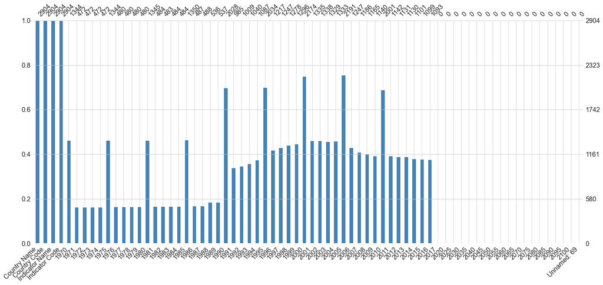

```python
#Affichage des données manquantes de Data
Data1=Data.iloc[:,:]
msno.bar(Data1,labels=True,color='steelblue')
```

Il n'y a plus de données après 2016.

Les données avant 2000 sont trop anciennes pour notre sujet.

## Restriction de la plage de temps

```python
#Data2 sous tableau contenant les codes indicateurs de 2000 à 2016 de Data1
Data2=pd.concat([Data1.iloc[:,:4],Data1.iloc[0:,31:48]],axis=1)
Data2.sample(5)
```

|  | Country Name | Country Code | Indicator Name | Indicator Code | 1997 | 1998 | 1999 | 2000 | 2001 | 2002 | ... | 2004 | 2005 | 2006 | 2007 | 2008 | 2009 | 2010 | 2011 | 2012 | 2013 |
| --- | --- | --- | --- | --- | --- | --- | --- | --- | --- | --- | --- | --- | --- | --- | --- | --- | --- | --- | --- | --- | --- |
| 308245 | El Salvador | SLV | Barro-Lee: Percentage of population age 15-19 ... | BAR.SEC.ICMP.1519.ZS | NaN | NaN | NaN | 36.040000 | NaN | NaN | ... | NaN | 44.560000 | NaN | NaN | NaN | NaN | 42.03000 | NaN | NaN | NaN |
| 558455 | Mexico | MEX | Internet users (per 100 people) | IT.NET.USER.P2 | 0.627312 | 1.265783 | 1.857436 | 5.081384 | 7.038023 | 11.900000 | ... | 14.100000 | 17.210000 | 19.520000 | 20.810000 | 21.710000 | 26.340000 | 31.05000 | 37.176295 | 39.750000 | 43.46000 |
| 355989 | Germany | DEU | Barro-Lee: Population in thousands, age 20-24,... | BAR.POP.2024 | NaN | NaN | NaN | 4482.000000 | NaN | NaN | ... | NaN | 4926.000000 | NaN | NaN | NaN | NaN | 5118.00000 | NaN | NaN | NaN |
| 576780 | Montenegro | MNE | Internet users (per 100 people) | IT.NET.USER.P2 | NaN | NaN | NaN | NaN | NaN | NaN | ... | 25.350069 | 27.100000 | 28.900000 | 30.800000 | 32.900000 | 35.100000 | 37.50000 | 35.611541 | 56.838783 | 60.31000 |
| 504412 | Libya | LBY | Population growth (annual %) | SP.POP.GROW | 1.603182 | 1.517235 | 1.502674 | 1.535094 | 1.571216 | 1.585525 | ... | 1.568962 | 1.529569 | 1.520435 | 1.500678 | 1.375934 | 1.116724 | 0.78253 | 0.394107 | 0.076777 | -0.03692 |

5 rows × 21 columns

## Remplissage des indicateurs par années

| Indicator Code | Country Name | Country Code | Indicator Name | 1997 | 1998 | 1999 | 2000 | 2001 | 2002 | 2003 | 2004 | 2005 | 2006 | 2007 | 2008 | 2009 | 2010 | 2011 | 2012 | 2013 |
| --- | --- | --- | --- | --- | --- | --- | --- | --- | --- | --- | --- | --- | --- | --- | --- | --- | --- | --- | --- | --- |
| BAR.POP.1519 | 242 | 242 | 242 | 0 | 0 | 0 | 144 | 0 | 0 | 0 | 0 | 144 | 0 | 0 | 0 | 0 | 144 | 0 | 0 | 0 |
| BAR.POP.2024 | 242 | 242 | 242 | 0 | 0 | 0 | 144 | 0 | 0 | 0 | 0 | 144 | 0 | 0 | 0 | 0 | 144 | 0 | 0 | 0 |
| BAR.POP.2529 | 242 | 242 | 242 | 0 | 0 | 0 | 144 | 0 | 0 | 0 | 0 | 144 | 0 | 0 | 0 | 0 | 144 | 0 | 0 | 0 |
| BAR.SEC.ICMP.1519.ZS | 242 | 242 | 242 | 0 | 0 | 0 | 144 | 0 | 0 | 0 | 0 | 144 | 0 | 0 | 0 | 0 | 144 | 0 | 0 | 0 |
| BAR.TER.ICMP.2024.ZS | 242 | 242 | 242 | 0 | 0 | 0 | 144 | 0 | 0 | 0 | 0 | 144 | 0 | 0 | 0 | 0 | 144 | 0 | 0 | 0 |
| BAR.TER.ICMP.2529.ZS | 242 | 242 | 242 | 0 | 0 | 0 | 144 | 0 | 0 | 0 | 0 | 144 | 0 | 0 | 0 | 0 | 144 | 0 | 0 | 0 |
| IT.CMP.PCMP.P2 | 242 | 242 | 242 | 153 | 176 | 183 | 187 | 207 | 206 | 203 | 204 | 196 | 117 | 49 | 27 | 3 | 0 | 0 | 0 | 0 |
| IT.NET.USER.P2 | 242 | 242 | 242 | 206 | 212 | 219 | 221 | 222 | 224 | 218 | 221 | 223 | 222 | 229 | 228 | 227 | 227 | 229 | 227 | 226 |
| NY.GDP.MKTP.PP.CD | 242 | 242 | 242 | 206 | 206 | 207 | 211 | 213 | 214 | 214 | 214 | 214 | 214 | 214 | 215 | 215 | 215 | 217 | 213 | 213 |
| NY.GDP.PCAP.PP.CD | 242 | 242 | 242 | 206 | 206 | 207 | 211 | 213 | 214 | 214 | 214 | 214 | 214 | 214 | 215 | 215 | 215 | 217 | 213 | 213 |
| SP.POP.GROW | 242 | 242 | 242 | 238 | 238 | 240 | 240 | 240 | 240 | 240 | 240 | 240 | 240 | 240 | 240 | 240 | 240 | 239 | 239 | 239 |
| SP.POP.TOTL | 242 | 242 | 242 | 238 | 240 | 240 | 240 | 240 | 240 | 240 | 240 | 240 | 240 | 240 | 240 | 240 | 240 | 240 | 239 | 239 |

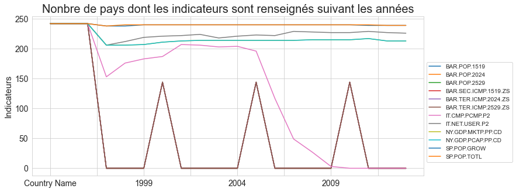

```python
#Comptage du nombre de pays renseignant les indicateurs suivant les années
Data3=Data2.groupby(['Indicator Code']).count()
display(Data3)

# Nombre de pays renseignés suivant les années pour les différents indices
f=plt.figure()
f.set_size_inches(12,5)
ax=f.add_subplot(111)
ax.set_title('Nonbre de pays dont les indicateurs sont renseignés suivant les années',fontsize=20)
ax.set_ylabel('Indicateurs',fontsize=15,)
ax.tick_params(labelsize=14)
Data3.T.plot(ax=ax)
ax.legend(loc='center left', bbox_to_anchor=(1, .40))
```

## Recherche de données plus récentes sur le site Data Bank

A ce stade, je vais sur le site DataBank pour faire une extraction des indices selectionnés sur la peridode 2000 à 2020 pour voir si on peut obtenir des données plus récentes.

Cette extraction est stockée dans le fichier EdStatsData_last.csv.

```
 EdStatsData_last.csv
(3221, 25)
```

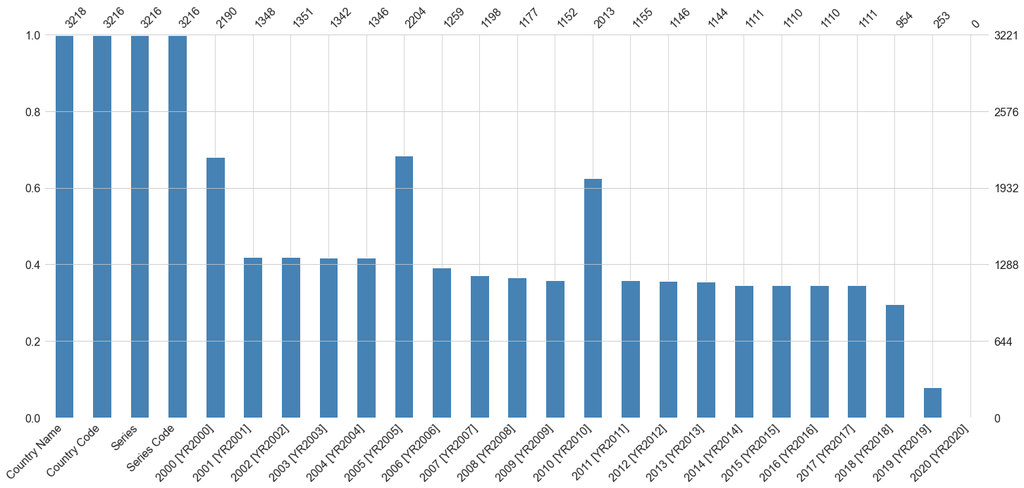

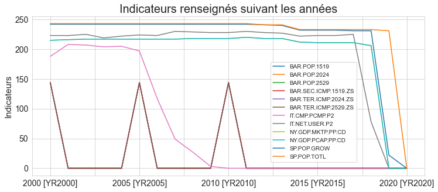

```python
#Chargement du fichier contenant l'extraction depuis le dashboard de DataBank
file='EdStatsData_last.csv'
print('\n\n\n',file)

EdStatsData_last = pd.read_csv('../Données/'+file)
print(EdStatsData_last.shape)
#aaffichage des données manquantes
msno.bar(EdStatsData_last,labels=True,color='steelblue')
# renomage des colonnes se raportant aux indicateurs
EdStatsData_last=EdStatsData_last.rename({'Series':'Indicator Name','Series Code':'Indicator Code'},axis=1)
# sous tableau ne contenant que indicator code et les valeurs des indices
data1=EdStatsData_last.iloc[:,3:]
# groupby pour avoir le nombre de pays qui renseignent chaque indicateur
data3=data1.groupby(['Indicator Code']).count()
# Nombre de pays renseignés suivant les années pour les différents indices
data4=data3.iloc[:,0:21]
# tracé de la figure
f=plt.figure()
f.set_size_inches(12,5)
ax=f.add_subplot(111)
ax.set_title('Indicateurs renseignés suivant les années',fontsize=20)
ax.set_ylabel('Indicateurs',fontsize=15,)
ax.tick_params(labelsize=14)
data4.T.plot(ax=ax)
ax.legend(loc='center left', bbox_to_anchor=(0.6, .40))
```

Il y a de nouvelles données pour les années 2017, 2018 et 2019. Je vais donc compléter mon jeu de données avec ces 3 années.

La suite du traitement est donc effectuée avec cette nouvelle extraction qui donne des renseignements plus récents.

```python
# enregistrement de la table qui va être étudiée dans Data4
Data4=EdStatsData_last
```

```python
#Nettoyage de la mémoire pour la suite du traitement
del(Data1)
del(Data2)
del(Data3)
del(data1)
del(data4)
```

## Création d'une table contenant la dernière valeur renseignée de chaque indicateur

Ajout de colonnes Last year et Last value

```python
# Suppression de slignes vides
Data4.dropna(how='all',subset=Data4.columns.to_series().loc['2000 [YR2000]':'2020 [YR2020]'],inplace=True)
# Rest de l'inde
Data4.reset_index(inplace=True,drop=True)
# Création des deux colonnes Last year et Last value initialisées à Nan
Data4['Last year']=np.nan
Data4['Last value']=np.nan
# Remplissage des deux colonnes avec la dernière valeur connue et son année de renseignement
for ind in Data4.index:
    col=Data4.iloc[ind,4:].last_valid_index()
    val=Data4.loc[ind,col]
    (Data4.loc[ind,'Last value'],Data4.loc[ind,'Last year'])=(val,int(col[:4]))
```

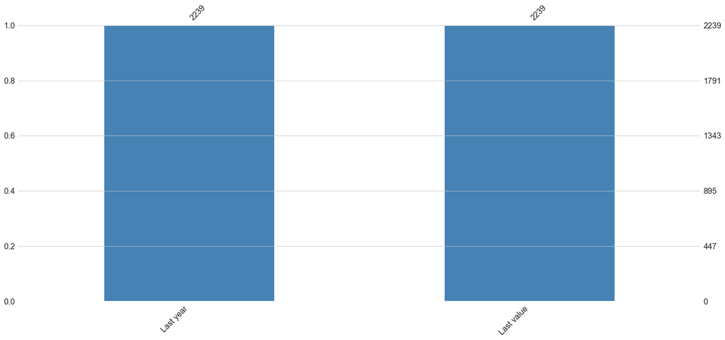

```python
# Affichage du remplissage des deux colonnes
msno.bar(Data4.iloc[:,-2:],labels=True,color='steelblue')
```

Création de deux tables :

- Data6 contient la dernière valeur connue
- Data7 l'année de renseignement

```python
# Mise en forme des jeux de données
# dans Data5 on reprend les colonnes country name, indicator code, last value et last year
Data5=pd.concat([Data4.iloc[:,0],Data4.iloc[:,3],Data4.iloc[:,-2:]],axis=1)
# drop des pays n'ayant pas tous leurs indicateurs de renseignés
Data5.drop(Data5[Data5['Indicator Code'].isna()].index,inplace=True)

# table contenant la dernière valeur connue
Data6=Data5.pivot(index='Country Name',columns='Indicator Code',values='Last value')
# table contenant l'année du dernier renseignement
Data7=Data5.pivot(index='Country Name',columns='Indicator Code',values='Last year')


print('Echantillon de la table contenant la dernière valeur')
display(Data6.sample(3))
print('Echantillon de la table contenant la dernière année de renseignement')
display(Data7.sample(3))
```

```
Echantillon de la table contenant la dernière valeur
```

| Indicator Code Country Name | BAR.POP.1519 | BAR.POP.2024 | BAR.POP.2529 | BAR.SEC.ICMP.1519.ZS | BAR.TER.ICMP.2024.ZS | BAR.TER.ICMP.2529.ZS | IT.CMP.PCMP.P2 | IT.NET.USER.P2 | NY.GDP.MKTP.PP.CD | NY.GDP.PCAP.PP.CD | SP.POP.GROW | SP.POP.TOTL |
| --- | --- | --- | --- | --- | --- | --- | --- | --- | --- | --- | --- | --- |
| Myanmar | 5362.0 | 5003.0 | 4798.0 | 21.71 | 22.60 | 16.00 | 0.912759 | 30.678183 | 3.584514e+11 | 6674.028647 | 0.608483 | 54045000.0 |
| Grenada | NaN | NaN | NaN | NaN | NaN | NaN | 15.333455 | 59.071735 | 1.733951e+09 | 15557.545037 | 0.521753 | 112000.0 |
| Spain | 1998.0 | 2324.0 | 3025.0 | 78.58 | 21.09 | 37.38 | 38.829757 | 86.107236 | 1.855654e+12 | 39715.439059 | 0.435389 | 46719000.0 |

```
Echantillon de la table contenant la dernière année de renseignement
```

| Indicator Code Country Name | BAR.POP.1519 | BAR.POP.2024 | BAR.POP.2529 | BAR.SEC.ICMP.1519.ZS | BAR.TER.ICMP.2024.ZS | BAR.TER.ICMP.2529.ZS | IT.CMP.PCMP.P2 | IT.NET.USER.P2 | NY.GDP.MKTP.PP.CD | NY.GDP.PCAP.PP.CD | SP.POP.GROW | SP.POP.TOTL |
| --- | --- | --- | --- | --- | --- | --- | --- | --- | --- | --- | --- | --- |
| Tonga | 2010.0 | 2010.0 | 2010.0 | 2010.0 | 2010.0 | 2010.0 | 2005.0 | 2017.0 | 2018.0 | 2018.0 | 2018.0 | 2019.0 |
| South Africa | 2010.0 | 2010.0 | 2010.0 | 2010.0 | 2010.0 | 2010.0 | 2005.0 | 2017.0 | 2018.0 | 2018.0 | 2018.0 | 2019.0 |
| Monaco | NaN | NaN | NaN | NaN | NaN | NaN | NaN | 2017.0 | NaN | NaN | 2018.0 | 2019.0 |

Etudions les années de renseignement des indicateurs.

```python
Data7.describe()
```

| Indicator Code | BAR.POP.1519 | BAR.POP.2024 | BAR.POP.2529 | BAR.SEC.ICMP.1519.ZS | BAR.TER.ICMP.2024.ZS | BAR.TER.ICMP.2529.ZS | IT.CMP.PCMP.P2 | IT.NET.USER.P2 | NY.GDP.MKTP.PP.CD | NY.GDP.PCAP.PP.CD | SP.POP.GROW | SP.POP.TOTL |
| --- | --- | --- | --- | --- | --- | --- | --- | --- | --- | --- | --- | --- |
| count | 144.0 | 144.0 | 144.0 | 144.0 | 144.0 | 144.0 | 217.000000 | 233.000000 | 220.000000 | 220.000000 | 242.000000 | 243.000000 |
| mean | 2010.0 | 2010.0 | 2010.0 | 2010.0 | 2010.0 | 2010.0 | 2005.788018 | 2017.111588 | 2017.759091 | 2017.759091 | 2017.863636 | 2018.728395 |
| std | 0.0 | 0.0 | 0.0 | 0.0 | 0.0 | 0.0 | 1.330290 | 1.638832 | 1.081669 | 1.081669 | 1.127734 | 1.285768 |
| min | 2010.0 | 2010.0 | 2010.0 | 2010.0 | 2010.0 | 2010.0 | 2000.000000 | 2000.000000 | 2011.000000 | 2011.000000 | 2011.000000 | 2011.000000 |
| 25% | 2010.0 | 2010.0 | 2010.0 | 2010.0 | 2010.0 | 2010.0 | 2005.000000 | 2017.000000 | 2018.000000 | 2018.000000 | 2018.000000 | 2019.000000 |
| 50% | 2010.0 | 2010.0 | 2010.0 | 2010.0 | 2010.0 | 2010.0 | 2006.000000 | 2017.000000 | 2018.000000 | 2018.000000 | 2018.000000 | 2019.000000 |
| 75% | 2010.0 | 2010.0 | 2010.0 | 2010.0 | 2010.0 | 2010.0 | 2006.000000 | 2018.000000 | 2018.000000 | 2018.000000 | 2018.000000 | 2019.000000 |
| max | 2010.0 | 2010.0 | 2010.0 | 2010.0 | 2010.0 | 2010.0 | 2009.000000 | 2018.000000 | 2018.000000 | 2018.000000 | 2019.000000 | 2019.000000 |

Tracé recapitulatif date-valeurs pour les indicateurs

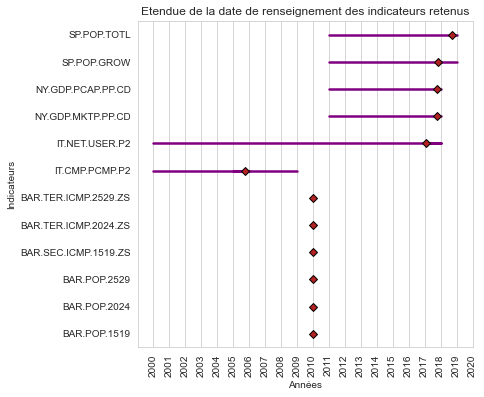

```python
plt.figure(figsize=(10,6))

boxprops = dict( linestyle='-', linewidth=2.5, color='purple')
flierprops = dict(marker=' ',)
medianprops = dict(linestyle='',)
meanpointprops = dict(marker='D', markeredgecolor='black',
                      markerfacecolor='firebrick')

whiskerprops= dict(linestyle='-', linewidth=2.5, color='purple')

Data7.plot.box(figsize=(6,6),vert=0,xticks=range(2000,2021,1),whis=[0, 100],whiskerprops=whiskerprops,
                                                                            boxprops=boxprops,
                                                                            flierprops=flierprops,
                                                                            medianprops=medianprops,
                                                                            meanprops=meanpointprops,
                                                                            meanline=False,
                                                                            showmeans=True,
                                                                            widths = 0).grid(axis='y')
plt.xticks(rotation=90)
plt.title('Etendue de la date de renseignement des indicateurs retenus')
plt.ylabel('Indicateurs')
plt.xlabel('Années')
plt.show()
```

Série IT.NET.USER.P2 : Il y a trés peu de pays dont les valeurs sont antérieures à 2017

Série Barrow-Lee BAR.* :Toutes les valeurs ont été renseignées en 2010, cette étude étant publiée tous les 5 ans.Les valeurs étant données toutes à la même date je conserve ces indicateurs.La périodicité de 5 ans des publications laisse espérer dans un futur proche une mise à jour.

Série NY.* : valeurs renseignées entre 2011 et 2018

Série SP.* : valeurs renseignées entre 2011 et 2019

Les pays dont les valeurs de l'indice IT.NET.USER.P2IT.NET.USER.P2 sont antérieures à 2010 vont donc être exclus.

```python
# Affichage des pays concernés
mask=Data7['IT.NET.USER.P2']<=2010
Data7[mask]
```

| Indicator Code Country Name | BAR.POP.1519 | BAR.POP.2024 | BAR.POP.2529 | BAR.SEC.ICMP.1519.ZS | BAR.TER.ICMP.2024.ZS | BAR.TER.ICMP.2529.ZS | IT.CMP.PCMP.P2 | IT.NET.USER.P2 | NY.GDP.MKTP.PP.CD | NY.GDP.PCAP.PP.CD | SP.POP.GROW | SP.POP.TOTL |
| --- | --- | --- | --- | --- | --- | --- | --- | --- | --- | --- | --- | --- |
| Mayotte | NaN | NaN | NaN | NaN | NaN | NaN | NaN | 2000.0 | NaN | NaN | 2016.0 | 2019.0 |
| Palau | NaN | NaN | NaN | NaN | NaN | NaN | NaN | 2004.0 | 2018.0 | 2018.0 | 2018.0 | 2019.0 |

Les deux pays concernés sont Mayotte et Palau. Ils vont donc être exlus.

```python
Data6.drop(Data6[mask].index.to_list(),inplace=True)
```

## Création d'un indicateur recensant le nombre de personnes scolarisées âgées de 15 à 29 ans

```python
#Population 15-19, 20-24 et 25-29
# Changement des valeurs des indices renseignés en milliers
Data6.loc[:,'BAR.POP.1519':'BAR.POP.2529']=Data6.loc[:,'BAR.POP.1519':'BAR.POP.2529']*1000

### Epression du nombre d'individus scolarises par tranches d'âge
Data6.loc[:,'BAR.SEC.ICMP.1519.ZS']=Data6.loc[:,'BAR.SEC.ICMP.1519.ZS']/100*Data6.loc[:,'BAR.POP.1519']
Data6.rename(columns={'BAR.SEC.ICMP.1519.ZS':'BAR.SEC.ICMP.1519'},inplace=True)

Data6.loc[:,'BAR.TER.ICMP.2024.ZS']=Data6.loc[:,'BAR.TER.ICMP.2024.ZS']/100*Data6.loc[:,'BAR.POP.2024']
Data6.rename(columns={'BAR.TER.ICMP.2024.ZS':'BAR.TER.ICMP.2024'},inplace=True)

Data6.loc[:,'BAR.TER.ICMP.2529.ZS']=Data6.loc[:,'BAR.TER.ICMP.2529.ZS']/100*Data6.loc[:,'BAR.POP.2529']
Data6.rename(columns={'BAR.TER.ICMP.2529.ZS':'BAR.TER.ICMP.2529'},inplace=True)
```

```python
#Création d'un indice recensant le nombre total individus scolarisés par pays âgés de 15 à 29 ans
Data6['POP 1529']=Data6['BAR.POP.1519']+Data6['BAR.POP.2024']+Data6['BAR.POP.2529']

#Création d'un indice recenssant le nombre total individus scolarisés par pays âgés de 15 à 29 ans
Data6['Student 1529']=Data6['BAR.SEC.ICMP.1519']+Data6['BAR.TER.ICMP.2024']+Data6['BAR.TER.ICMP.2529']
```

```python
Data6.info()
```

```
<class 'pandas.core.frame.DataFrame'>
Index: 241 entries, Afghanistan to Zimbabwe
Data columns (total 14 columns):
 #   Column             Non-Null Count  Dtype
---  ------             --------------  -----
 0   BAR.POP.1519       144 non-null    float64
 1   BAR.POP.2024       144 non-null    float64
 2   BAR.POP.2529       144 non-null    float64
 3   BAR.SEC.ICMP.1519  144 non-null    float64
 4   BAR.TER.ICMP.2024  144 non-null    float64
 5   BAR.TER.ICMP.2529  144 non-null    float64
 6   IT.CMP.PCMP.P2     217 non-null    float64
 7   IT.NET.USER.P2     231 non-null    float64
 8   NY.GDP.MKTP.PP.CD  219 non-null    float64
 9   NY.GDP.PCAP.PP.CD  219 non-null    float64
 10  SP.POP.GROW        240 non-null    float64
 11  SP.POP.TOTL        241 non-null    float64
 12  POP 1529           144 non-null    float64
 13  Student 1529       144 non-null    float64
dtypes: float64(14)
memory usage: 28.2+ KB
```

Supression des colonnes agrégées

```python
# exclusion des 6 premières colonnes dont on a plus besoin maintenant
Data6=Data6.iloc[:,6:]
```

Remplissage des diffrénts indicateurs

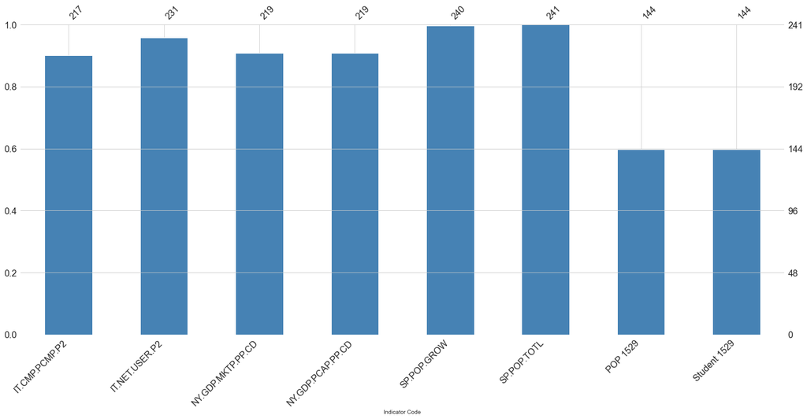

```python
msno.bar(Data6,labels=True,color='steelblue')
```

## Contenu de la colonne Country Name

### Zones géographiques et économiques

```python
#La dernières des zones est 'World' le premier pays est 'Afghanistan'
ind=EdStatsData.loc[EdStatsData['Country Name']=='Afghanistan'].index[0]
Regions=EdStatsData.iloc[:ind,0].unique()
display(Regions)
```

```
array(['Arab World', 'East Asia & Pacific',
       'East Asia & Pacific (excluding high income)', 'Euro area',
       'Europe & Central Asia',
       'Europe & Central Asia (excluding high income)', 'European Union',
       'Heavily indebted poor countries (HIPC)', 'High income',
       'Latin America & Caribbean',
       'Latin America & Caribbean (excluding high income)',
       'Least developed countries: UN classification',
       'Low & middle income', 'Low income', 'Lower middle income',
       'Middle East & North Africa',
       'Middle East & North Africa (excluding high income)',
       'Middle income', 'North America', 'OECD members', 'South Asia',
       'Sub-Saharan Africa', 'Sub-Saharan Africa (excluding high income)',
       'Upper middle income', 'World'], dtype=object)
```

On remarque qu'il y a des régions géographiques ainsi que des groupes économiques.

### Pays

```python
Pays=EdStatsData.iloc[ind:,0].unique()
display(Pays)
```

```
array(['Afghanistan', 'Albania', 'Algeria', 'American Samoa', 'Andorra',
       'Angola', 'Antigua and Barbuda', 'Argentina', 'Armenia', 'Aruba',
       'Australia', 'Austria', 'Azerbaijan', 'Bahamas, The', 'Bahrain',
       'Bangladesh', 'Barbados', 'Belarus', 'Belgium', 'Belize', 'Benin',
       'Bermuda', 'Bhutan', 'Bolivia', 'Bosnia and Herzegovina',
       'Botswana', 'Brazil', 'British Virgin Islands',
       'Brunei Darussalam', 'Bulgaria', 'Burkina Faso', 'Burundi',
       'Cabo Verde', 'Cambodia', 'Cameroon', 'Canada', 'Cayman Islands',
       'Central African Republic', 'Chad', 'Channel Islands', 'Chile',
       'China', 'Colombia', 'Comoros', 'Congo, Dem. Rep.', 'Congo, Rep.',
       'Costa Rica', "Cote d'Ivoire", 'Croatia', 'Cuba', 'Curacao',
       'Cyprus', 'Czech Republic', 'Denmark', 'Djibouti', 'Dominica',
       'Dominican Republic', 'Ecuador', 'Egypt, Arab Rep.', 'El Salvador',
       'Equatorial Guinea', 'Eritrea', 'Estonia', 'Ethiopia',
       'Faroe Islands', 'Fiji', 'Finland', 'France', 'French Polynesia',
       'Gabon', 'Gambia, The', 'Georgia', 'Germany', 'Ghana', 'Gibraltar',
       'Greece', 'Greenland', 'Grenada', 'Guam', 'Guatemala', 'Guinea',
       'Guinea-Bissau', 'Guyana', 'Haiti', 'Honduras',
       'Hong Kong SAR, China', 'Hungary', 'Iceland', 'India', 'Indonesia',
       'Iran, Islamic Rep.', 'Iraq', 'Ireland', 'Isle of Man', 'Israel',
       'Italy', 'Jamaica', 'Japan', 'Jordan', 'Kazakhstan', 'Kenya',
       'Kiribati', 'Korea, Dem. People’s Rep.', 'Korea, Rep.', 'Kosovo',
       'Kuwait', 'Kyrgyz Republic', 'Lao PDR', 'Latvia', 'Lebanon',
       'Lesotho', 'Liberia', 'Libya', 'Liechtenstein', 'Lithuania',
       'Luxembourg', 'Macao SAR, China', 'Macedonia, FYR', 'Madagascar',
       'Malawi', 'Malaysia', 'Maldives', 'Mali', 'Malta',
       'Marshall Islands', 'Mauritania', 'Mauritius', 'Mexico',
       'Micronesia, Fed. Sts.', 'Moldova', 'Monaco', 'Mongolia',
       'Montenegro', 'Morocco', 'Mozambique', 'Myanmar', 'Namibia',
       'Nauru', 'Nepal', 'Netherlands', 'New Caledonia', 'New Zealand',
       'Nicaragua', 'Niger', 'Nigeria', 'Northern Mariana Islands',
       'Norway', 'Oman', 'Pakistan', 'Palau', 'Panama',
       'Papua New Guinea', 'Paraguay', 'Peru', 'Philippines', 'Poland',
       'Portugal', 'Puerto Rico', 'Qatar', 'Romania',
       'Russian Federation', 'Rwanda', 'Samoa', 'San Marino',
       'Sao Tome and Principe', 'Saudi Arabia', 'Senegal', 'Serbia',
       'Seychelles', 'Sierra Leone', 'Singapore',
       'Sint Maarten (Dutch part)', 'Slovak Republic', 'Slovenia',
       'Solomon Islands', 'Somalia', 'South Africa', 'South Sudan',
       'Spain', 'Sri Lanka', 'St. Kitts and Nevis', 'St. Lucia',
       'St. Martin (French part)', 'St. Vincent and the Grenadines',
       'Sudan', 'Suriname', 'Swaziland', 'Sweden', 'Switzerland',
       'Syrian Arab Republic', 'Tajikistan', 'Tanzania', 'Thailand',
       'Timor-Leste', 'Togo', 'Tonga', 'Trinidad and Tobago', 'Tunisia',
       'Turkey', 'Turkmenistan', 'Turks and Caicos Islands', 'Tuvalu',
       'Uganda', 'Ukraine', 'United Arab Emirates', 'United Kingdom',
       'United States', 'Uruguay', 'Uzbekistan', 'Vanuatu',
       'Venezuela, RB', 'Vietnam', 'Virgin Islands (U.S.)',
       'West Bank and Gaza', 'Yemen, Rep.', 'Zambia', 'Zimbabwe'],
      dtype=object)
```

Dans cette liste, il y a uniquement des pays.

Nombre de Pays

```python
len(Pays)
```

```
217
```

### Suppression des zones économiques et des régions

Etant donné que mon jeu de données contient des valeurs pour des pays et des zones géographiques ou économiques. Le dataframe DataPays, ne contenant que les indicateurs des pays, est créé.

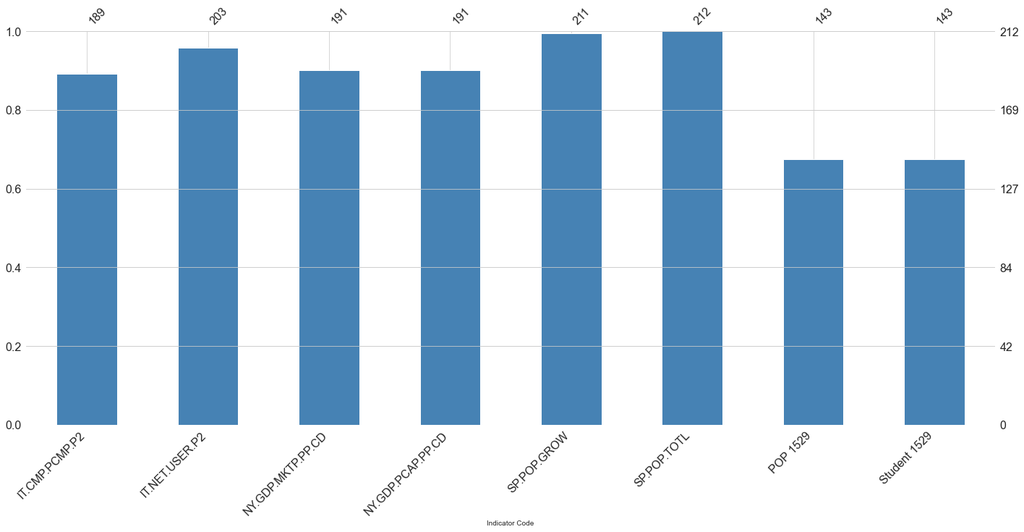

```python
#la liste Pays a été créé au moment de l'étude du jeu de données initial
DataPays=Data6[Data6.index.isin(Pays)].copy()
# remplissage
msno.bar(DataPays,labels=True,color='steelblue')
```

Indicateurs remplis à plus de 60%

## Etude des outliers

```python
#Caractérisation des outliers par un zscore 3 fois supérieur à l'écart type.
for col in DataPays.columns:
    print('SERIE :',col)
    Sx=DataPays[col].dropna()
    Sx=Sx[(np.abs(zscore(Sx))>=3)]
    for i in Sx.index:
        print(('Non du pays :'+i).ljust(35),'  Valeur :',Sx[i])
    print('')
```

```
SERIE : IT.CMP.PCMP.P2
Non du pays :Canada                   Valeur : 94.6615001567293
Non du pays :Netherlands              Valeur : 90.6320686550694
Non du pays :Sweden                   Valeur : 87.9491521976569
Non du pays :Switzerland              Valeur : 96.5521819284488

SERIE : IT.NET.USER.P2

SERIE : NY.GDP.MKTP.PP.CD
Non du pays :China                    Valeur : 25398677997933.1
Non du pays :India                    Valeur : 10500208396732.1
Non du pays :United States            Valeur : 20544343456936.5

SERIE : NY.GDP.PCAP.PP.CD
Non du pays :Luxembourg               Valeur : 113337.420494703
Non du pays :Macao SAR, China         Valeur : 123892.166434539
Non du pays :Qatar                    Valeur : 126898.425931605
Non du pays :Singapore                Valeur : 101531.630228067

SERIE : SP.POP.GROW
Non du pays :Bahrain                  Valeur : 4.92116137205662
Non du pays :Puerto Rico              Valeur : -3.98350008527716

SERIE : SP.POP.TOTL
Non du pays :China                    Valeur : 1397295000.0
Non du pays :India                    Valeur : 1366418000.0

SERIE : POP 1529
Non du pays :China                    Valeur : 317916000.0
Non du pays :India                    Valeur : 324667000.0

SERIE : Student 1529
Non du pays :China                    Valeur : 114355872.7
Non du pays :India                    Valeur : 107968614.89999999
```

Les outliers correspondent à des valeurs élevées mais non aberrantes, je choisis de les conserver pour le classement final.

## Etude de la distribution des indicateurs choisis

```python
DataPays.describe()
```

| Indicator Code | IT.CMP.PCMP.P2 | IT.NET.USER.P2 | NY.GDP.MKTP.PP.CD | NY.GDP.PCAP.PP.CD | SP.POP.GROW | SP.POP.TOTL | POP 1529 | Student 1529 |
| --- | --- | --- | --- | --- | --- | --- | --- | --- |
| count | 189.000000 | 203.000000 | 1.910000e+02 | 191.000000 | 211.000000 | 2.120000e+02 | 1.430000e+02 | 1.430000e+02 |
| mean | 17.200755 | 56.173938 | 7.033087e+11 | 22334.156700 | 1.255054 | 3.607441e+07 | 1.134569e+07 | 3.965756e+06 |
| std | 22.449618 | 28.913274 | 2.562499e+12 | 23743.182259 | 1.178168 | 1.391600e+08 | 3.875177e+07 | 1.378274e+07 |
| min | 0.021903 | 0.000000 | 4.660239e+07 | 744.182072 | -3.983500 | 1.200000e+04 | 2.900000e+04 | 1.184250e+04 |
| 25% | 2.228550 | 30.304706 | 2.193474e+10 | 4366.304695 | 0.472729 | 8.802500e+05 | 9.135000e+05 | 3.009777e+05 |
| 50% | 7.916958 | 62.000000 | 7.866099e+10 | 13799.904847 | 1.168658 | 6.905500e+06 | 2.380000e+06 | 6.557644e+05 |
| 75% | 21.159799 | 80.699179 | 3.974006e+11 | 31898.468244 | 1.998848 | 2.567875e+07 | 8.689000e+06 | 2.273146e+06 |
| max | 96.552182 | 99.652849 | 2.539868e+13 | 126898.425932 | 4.921161 | 1.397295e+09 | 3.246670e+08 | 1.143559e+08 |

## Corrélation entre les indicateurs

[figure not shown]

```python
sns.clustermap(DataPays.corr(method='pearson'),annot=True).fig.suptitle('Corrélation', x=.9,fontsize=15)
```

On note tout d'abord des corrélations entre les indicateurs comptant la population totale et les populations par tranches d'âge.

Par ailleurs, l'indicateur sur la croissance démographique est peu corrélé aux autres. Il est donc pertinent de le garder afin de pouvoir se projeter le vieillissement de la population et l'évolution du réservoir de client potentiel.

L'indice IT.NET.USER est conservé comme cela a été expliqué prédemment.

## Indice composite de la richesse potentielle des étudiants utilisant internet

Nombre d'étudiants entre 15 et 29 ans x PIB/habitant x IT.NET.USER.P2 = Richesse potentielle des étudiants utilisant internet

Cet indicateur, que je choisis de nommer CAP, va me permetre de comparer les pays sur un critère monétaire unifié (us$ courant) de la richesse potentielle des étudiants.

```python
# Création d'une nouvelle colone contenant les valeus de CAP
DataPays['CAP']=DataPays['Student 1529']*DataPays['NY.GDP.PCAP.PP.CD']*DataPays['IT.NET.USER.P2']/100
```

```python
# Descriptionde CAP
DataPays['CAP'].describe()
```

```
count    1.410000e+02
mean     6.227688e+10
std      2.330954e+11
min      4.236715e+06
25%      8.516836e+08
50%      5.448221e+09
75%      3.494606e+10
max      2.406163e+12
Name: CAP, dtype: float64
```

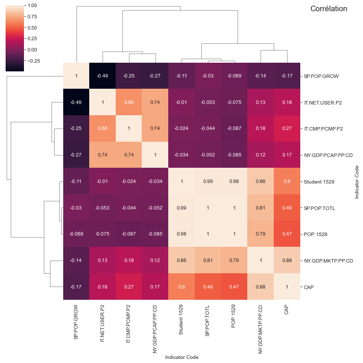

```python
sns.clustermap(DataPays.corr(method='pearson'),annot=True).fig.suptitle('Corrélation', x=.9,fontsize=15)
```

# V Analyse détaillée des indicateurs CAP, IT.NET.USER et SP.POP.GROW

## Jeu de données réduit aux indicateurs

```python
#Jeux de données réduits aux 3 indicateurs choisis pays non renseignés supprimés
DataSet=DataPays[['CAP', 'IT.NET.USER.P2', 'SP.POP.GROW']].copy()
```

## Données manquantes

```python
tmp=DataSet.count()/DataSet.shape[0]
display(tmp)
```

[output not shown]

[figure not shown]

```python
tmp.plot(kind='bar')
plt.ylabel('Remplissage')
plt.title('Taux de remplissage des indicateurs')
```

## Pays CAP non renseigné

```python
# masque de selection pour les lignes où CAP n'est pas renseigné
mask=DataSet['CAP'].isna()
tmp=DataSet[mask==True]
# affichage des index des lignes afin de connaître les noms des pays concernés
display(tmp.index,len(tmp.index))
```

```
Index(['American Samoa', 'Andorra', 'Angola', 'Antigua and Barbuda', 'Aruba',
       'Azerbaijan', 'Bahamas, The', 'Belarus', 'Bermuda', 'Bhutan',
       'Bosnia and Herzegovina', 'Burkina Faso', 'Cabo Verde',
       'Cayman Islands', 'Chad', 'Channel Islands', 'Comoros', 'Cuba',
       'Curacao', 'Djibouti', 'Dominica', 'Equatorial Guinea', 'Eritrea',
       'Ethiopia', 'Faroe Islands', 'French Polynesia', 'Georgia', 'Gibraltar',
       'Greenland', 'Grenada', 'Guam', 'Guinea', 'Guinea-Bissau',
       'Isle of Man', 'Kiribati', 'Korea, Dem. People’s Rep.', 'Kosovo',
       'Lebanon', 'Liechtenstein', 'Madagascar', 'Marshall Islands',
       'Micronesia, Fed. Sts.', 'Monaco', 'Montenegro', 'New Caledonia',
       'Nigeria', 'Northern Mariana Islands', 'Oman', 'Puerto Rico', 'Samoa',
       'San Marino', 'Sao Tome and Principe', 'Seychelles',
       'Sint Maarten (Dutch part)', 'Solomon Islands', 'Somalia',
       'South Sudan', 'St. Kitts and Nevis', 'St. Lucia',
       'St. Martin (French part)', 'St. Vincent and the Grenadines',
       'Suriname', 'Syrian Arab Republic', 'Timor-Leste', 'Turkmenistan',
       'Turks and Caicos Islands', 'Tuvalu', 'Uzbekistan', 'Vanuatu',
       'Virgin Islands (U.S.)', 'West Bank and Gaza'],
      dtype='object', name='Country Name')
```

```
71
```

Liste des 71 pays écartés pour cause de non renseignement de l'indicateur CAP

```python
#Suppression des lignes vides
DataSet.dropna(inplace=True)
display(DataSet.info())
```

```
<class 'pandas.core.frame.DataFrame'>
Index: 140 entries, Afghanistan to Zimbabwe
Data columns (total 3 columns):
 #   Column          Non-Null Count  Dtype
---  ------          --------------  -----
 0   CAP             140 non-null    float64
 1   IT.NET.USER.P2  140 non-null    float64
 2   SP.POP.GROW     140 non-null    float64
dtypes: float64(3)
memory usage: 4.4+ KB
```

```
None
```

Table ne contenant plus que 140 pays ayant les trois indicateurs renseignés (remplie à 100%).

## Etude des indicateurs retenus

Fonction permettant de tracer des boxplots simples avec distribution

```python
#fonction permettant de tracer des boxplots simples avec distribution
def Boite(Sx,outliers,titre,xlabel,notation,tab):
    # série à traiter, True affichage des outliers, titre de la figure, xlabel, True axe des abscisses en milliards,sinon %, tab= espacement des affichages text
    f=plt.figure()
    f.set_size_inches(12,2)
    ax=f.add_subplot(111)
    ax.set_title(titre,fontsize=20)
    ax.set_xlabel(xlabel,fontsize=15,)
    ax.tick_params(labelsize=14)
    #formatage des valeurs de l'axe des absices
    if ~notation:
        ax.xaxis.set_major_formatter(PercentFormatter(xmax=100, decimals=1, symbol='%', is_latex=False))
    #tracé du boxplot
    ax=Sx.plot(kind='box',vert=False,showmeans=True,showfliers=outliers,
               color=dict(boxes='k', whiskers='k', medians='orange', caps='k'),meanprops={'marker':"d"})

    xmin, xmax, ymin, ymax = ax.axis()
    #outliers
    if not(outliers):
        min=2.5*Sx.quantile(.25)-1.5*Sx.quantile(.75)
        max=2.5*Sx.quantile(.75)-1.5*Sx.quantile(.25)
        V=Sx[operator.and_(Sx>min, Sx<max) ]
    else:
        V=Sx
    #tracé de la distribution
    ax.violinplot(V, vert=False, widths=0.6,
                  showmeans=False, showextrema=False, showmedians=False,
                  quantiles=None, points=100, bw_method=None,  data=None)
   #formatage des valeurs
    def form (x):
        if notation:
            return str('{:.1E}'.format(x)).ljust(l)
        else:
            return str('{:.1%}'.format(x/100)).ljust(l)
    i=0.55
    l=tab
    S=Sx
    #ajout des indicateurs statistiques
    ax.text(xmin,i,
          'Min = '+form(S.min())+
          'Médiane = '+form(S.median())+
          'Moyenne=  '+form(S.mean())+
          '\u03C3= '+form(S.std())+
          'Max = '+form(S.max()),
          fontsize=14)
    if notation:
        val=ax_1.get_xticks()
        ax.set_xticklabels(val/1E9)
        ax.set_xlabel('milliards US $',fontsize=12)
```

### Dispersion des indicateurs

Boxplots des indicateurs avec outliers

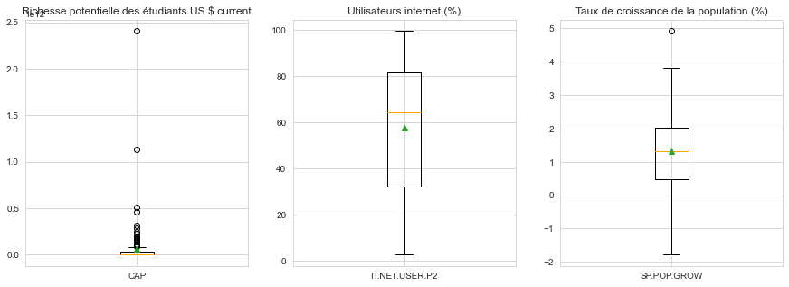

```python
f, (ax_1, ax_2,ax_3 ) = plt.subplots(1,3, sharex='none',figsize=(15,5))
c=dict(boxes='k', whiskers='k', medians='orange', caps='k')

ax_1.set_title('Richesse potentielle des étudiants US $ current')
DataSet['CAP'].plot(kind='box',ax=ax_1,logy=False,showmeans=True,color=c)
ax_2.set_title('Utilisateurs internet (%)')
DataSet['IT.NET.USER.P2'].plot(kind='box',ax=ax_2,logy=False,showmeans=True,color=c)
ax_3.set_title('Taux de croissance de la population (%)')
DataSet['SP.POP.GROW'].plot(kind='box',ax=ax_3,logy=False,showmeans=True,color=c)
```

Affichage des outliers

```python
#Caractérisation des outliers par un zscore 3 fois supérieur à l'écart type.
for col in DataSet.columns:
    print('SERIE :',col)
    Sx=DataSet[col].dropna().sort_values(ascending=False)
    min=2.5*Sx.quantile(.25)-1.5*Sx.quantile(.75)
    max=2.5*Sx.quantile(.75)-1.5*Sx.quantile(.25)
    V=Sx[operator.or_(Sx<min, Sx>max) ]

    for i in V.index:
        print(('Non du pays :'+i).ljust(35),'  Valeur :',V[i])
    print('')
```

```
SERIE : CAP
Non du pays :United States            Valeur : 2406162720168.2446
Non du pays :China                    Valeur : 1132406839386.5305
Non du pays :Russian Federation       Valeur : 509581677344.7338
Non du pays :Japan                    Valeur : 464070442601.7768
Non du pays :Korea, Rep.              Valeur : 315670365846.7533
Non du pays :India                    Valeur : 288741845544.8168
Non du pays :United Kingdom           Valeur : 250205231647.82733
Non du pays :France                   Valeur : 225810269452.23242
Non du pays :Germany                  Valeur : 197064753789.5562
Non du pays :Canada                   Valeur : 187488712803.61453
Non du pays :Mexico                   Valeur : 180505926796.29007
Non du pays :Iran, Islamic Rep.       Valeur : 174061381361.49402
Non du pays :Turkey                   Valeur : 156715587619.0558
Non du pays :Brazil                   Valeur : 146939977274.40976
Non du pays :Saudi Arabia             Valeur : 142770214826.98523
Non du pays :Italy                    Valeur : 112812686365.3319
Non du pays :Spain                    Valeur : 109122143691.51582
Non du pays :Malaysia                 Valeur : 98903837511.90773
Non du pays :Poland                   Valeur : 88681561730.97714
Non du pays :Indonesia                Valeur : 88610359507.4552

SERIE : IT.NET.USER.P2

SERIE : SP.POP.GROW
Non du pays :Bahrain                  Valeur : 4.92116137205662
```

Pas de valeurs aberrantes

Observation des outliers de CAP

```
Outliers CAP
```

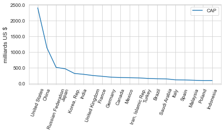

```python
print('Outliers CAP')

Sx=DataSet['CAP'].dropna().sort_values(ascending=False)
max=2.5*Sx.quantile(.75)-1.5*Sx.quantile(.25)
S=Sx[Sx>=max]
# Création d'une table contenant les nom des pays et les valeurs considérées comme outliers
df=pd.DataFrame(columns=DataPays.columns)
for row in S.index:
    df=pd.concat([df,DataPays.loc[row,:]],axis=1)

f, ax =   plt.subplots(1 ,figsize=(7,3))
ax.set_title('',fontsize=20)
ax.plot(S)
ax.set_xticklabels(S.index, rotation = 70)
ax.legend(['CAP'])
val=ax.get_yticks()
ax.set_yticklabels(val/1E9)
ax.set_ylabel('milliards US $',fontsize=12)
```

On observe des valeurs qui s'expliquent par des populations ou richesses élevées. Je choisis de les garder dans l'étude finale mais de les exclure des représentations suivantes.

### Dispersion sans les outliers

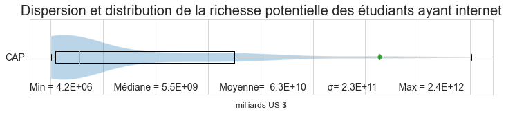

```python
Boite(DataSet.loc[:,'CAP'],False,'Dispersion et distribution de la richesse potentielle des étudiants ayant internet','Milliards US $',True,15)
```

Pour de nombreux de pays, la valeur de CAP est faible. Plus le PIB est petit et sa population étudiantes réduite, plus cet indicateur est faible. Au contraire, un pays avec un PIB élevé et une population étudiante nombreuse fera partie des pays pour lesquels cet indicateur est fort. Ces pays présenteront un potentiel de développement pour academy.

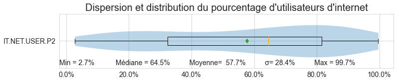

```python
Boite(DataSet.loc[:,'IT.NET.USER.P2'],False,'Dispersion et distribution du pourcentage d\'utilisateurs d\'internet',
                      '',False,15)
```

Plus de 50% des pays ont un taux d'utilisation d'internet supérieur à 60%. Ils ont donc des infrastructures réseau suffisamment développées pour envisager une implémentation d'academy.

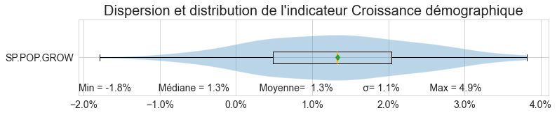

```python
Boite(DataSet.loc[:,'SP.POP.GROW'],False,'Dispersion et distribution de l\'indicateur Croissance démographique','',False,15)
```

Un quart des pays ont une croissance démographique supérieure à 2% par an. Ces pays présentent un intérêt à long terme pour academy.

# VI Classement par régions des pays selon les indicateurs étudiés

Création d'une table liant les pays aux régions géographiques

```python
table=Dic_Pays_Regions.pivot(columns='Region',values='Country Name').dropna(axis=1,how='all')
# suppression de la première colone qui des vide
table.drop(table.columns[0],axis=1,inplace=True)
```

[output not shown]

241 rows × 8 columns

```python
table.head(0)
```

| Region | East Asia & Pacific | Europe & Central Asia | Latin America & Caribbean | Middle East & North Africa | North America | South Asia | Sub-Saharan Africa |
| --- | --- | --- | --- | --- | --- | --- | --- |

Les régions sont au nombre de 7.

Vérfication de l'affectation de chaque pays à une région

```python
for ind in DataSet.index:
    try:
        Reg=table[table.isin([ind])].dropna(how='all',axis=1).dropna().columns[0]
    except:
       print('Erreur sur :',ind)
```

```
Erreur sur : Cote d'Ivoire
```

Vérification de l'orthographe du pays non trouvé

```python
table[table.isin(['Côte d\'Ivoire'])].dropna(how='all',axis=1).dropna()
```

| Region | Sub-Saharan Africa |
| --- | --- |
| 38 | Côte d'Ivoire |

Changement du nom dans l'index de DataSet

```python
DataSet=DataSet.rename(index={'Cote d\'Ivoire': 'Côte d\'Ivoire'})
```

Ajout d'une colonne Region

```python
DataSet['Region']=np.nan
for ind in DataSet.index:
    Reg=table[table.isin([ind])].dropna(how='all',axis=1).dropna().columns[0]
    DataSet.loc[ind,'Region']=Reg
```

Affichage de l'indicateur CAP par région

```python
df=DataSet.groupby('Region').sum()['CAP'].sort_values()
display(df)
```

```
Region
Sub-Saharan Africa            5.200141e+10
South Asia                    3.191055e+11
Middle East & North Africa    5.334261e+11
Latin America & Caribbean     5.740350e+11
Europe & Central Asia         2.235533e+12
East Asia & Pacific           2.471299e+12
North America                 2.593651e+12
Name: CAP, dtype: float64
```

Représentation de la répartition de l'indicateur CAP par région

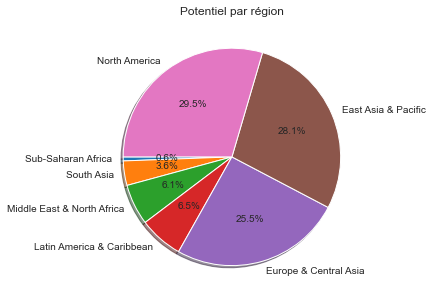

```python
plt.figure(figsize=(5,5))
plt.title('Potentiel par région')
plt.pie(df,  labels=df.index, autopct='%1.1f%%',
        shadow=True, startangle=180)
plt.show()
```

Regardons maintenant les pays les plus prometteurs de chaque région.

Création d'une table énumérant les valeurs de l'indicateur CAP des différents pays de chaque région

```python
df=DataSet.reset_index()
df1=df.pivot(index='Region',columns='Country Name',values='CAP')
df1
```

| Country Name Region | Afghanistan | Albania | Algeria | Argentina | Armenia | Australia | Austria | Bahrain | Bangladesh | Barbados | ... | Ukraine | United Arab Emirates | United Kingdom | United States | Uruguay | Venezuela, RB | Vietnam | Yemen, Rep. | Zambia | Zimbabwe |
| --- | --- | --- | --- | --- | --- | --- | --- | --- | --- | --- | --- | --- | --- | --- | --- | --- | --- | --- | --- | --- | --- |
| East Asia & Pacific | NaN | NaN | NaN | NaN | NaN | 8.027974e+10 | NaN | NaN | NaN | NaN | ... | NaN | NaN | NaN | NaN | NaN | NaN | 2.497654e+10 | NaN | NaN | NaN |
| Europe & Central Asia | NaN | 2.963908e+09 | NaN | NaN | 2.770166e+09 | NaN | 1.589938e+10 | NaN | NaN | NaN | ... | 3.256054e+10 | NaN | 2.502052e+11 | NaN | NaN | NaN | NaN | NaN | NaN | NaN |
| Latin America & Caribbean | NaN | NaN | NaN | 4.392824e+10 | NaN | NaN | NaN | NaN | NaN | 3.198094e+08 | ... | NaN | NaN | NaN | NaN | 2.802201e+09 | 3.494606e+10 | NaN | NaN | NaN | NaN |
| Middle East & North Africa | NaN | NaN | 2.863351e+10 | NaN | NaN | NaN | NaN | 2.897385e+09 | NaN | NaN | ... | NaN | 3.124104e+10 | NaN | NaN | NaN | NaN | NaN | 8.516836e+08 | NaN | NaN |
| North America | NaN | NaN | NaN | NaN | NaN | NaN | NaN | NaN | NaN | NaN | ... | NaN | NaN | NaN | 2.406163e+12 | NaN | NaN | NaN | NaN | NaN | NaN |
| South Asia | 4.184380e+08 | NaN | NaN | NaN | NaN | NaN | NaN | NaN | 7.633344e+09 | NaN | ... | NaN | NaN | NaN | NaN | NaN | NaN | NaN | NaN | NaN | NaN |
| Sub-Saharan Africa | NaN | NaN | NaN | NaN | NaN | NaN | NaN | NaN | NaN | NaN | ... | NaN | NaN | NaN | NaN | NaN | NaN | NaN | NaN | 7.468529e+08 | 7.426859e+08 |

7 rows × 140 columns

Fonction permettant de tracer un barplot horizontal avec unités des abscises en milliards

```python
def bar1(S,titre='',width=.5,size=(10,8)):
    # bar plot horizontal
    f, ax_1 = plt.subplots(1 ,figsize=size)
    ax_1.set_title(titre,fontsize=15)
    ax_1.barh(S.index,S,width)
    # valeurs dans les barres
    for index, value in enumerate(S):
        plt.text(value, index, '{:.1E}'.format(value), va='center')
    val=ax_1.get_xticks()
    # graduation des abscisses en milliards
    ax_1.set_xticklabels(val/1E9)
    ax_1.set_xlabel('milliars US $',fontsize=11)
```

Fonction permettant de tracer un barplot horizontal avec unités des abscises en pourcentages

```python
def bar2(Serie,titre='',width=.5,color='b',size=(5,5)):
    f, (ax_1)  = plt.subplots(1,1,sharey=False, figsize=size)
    #bar plot horizontal
    ax_1.set_title(titre,fontsize=15)
    ax_1.barh(Serie.index,Serie,width,color=color)
    # valeurs dans les barres
    for index, value in enumerate(Serie):
        ax_1.text(value, index, '{:.1%}'.format(value/100), va='center')
    # graduation des abscisses en %
    ax_1.xaxis.set_major_formatter(PercentFormatter(xmax=100, decimals=0, symbol='%'))
```

Fonction permettant de tracer un diagramme circulaire, contenant une portion Autres déterminée par le seuil part (en %), qui est explicitée (ou pas) dans un barplot horizontal sur le côté

```python
def Pie_Autres(S1,titre='',bar=True,part=5,width=0.5,size=(10,5)):
    #seuil de passage à Autres
    cut=cut=S1.sum()*part/100
    # serie contenant les affichages de pie
    S2=S1[S1>cut]
    #série contenant les affichages de bar
    S3=S1[S1<=cut]
    #ajout d'une part nommée Autre avec la bonne quantité
    S2['Autres']=S1.sum()-S2.sum()
    if bar :
        # tracé de pie avec portion autres representée en barres sur le côté
        f, (ax_1, ax_2 ) = plt.subplots(1,2, sharex='none',figsize=size,gridspec_kw={'width_ratios': [.8,.2]})
        plt.title(titre,fontsize=(20))
        ax_1.set_title(titre)
        ax_1.pie(S2,  labels=S2.index, autopct='%1.1f%%',
                shadow=False, startangle=35)
        draw_circle = plt.Circle((0, 0), 0.68,color='white')
        ax_1.add_artist(draw_circle)
        #affichage barh des pays Autre en %
        ax_2.set_title('Autres')
        ax_2.xaxis.set_major_formatter(PercentFormatter(xmax=100, decimals=1, symbol='%'))
        ax_2.barh(S3.index,S3/S1.sum()*100,width)
    else:
        # tracé de pie avec Autres mais sans barres sur le côté
        f, (ax_1 ) = plt.subplots(1, figsize=size)
        plt.title(titre)

        ax_1.set_title(titre)
        ax_1.pie(S2,  labels=S2.index, autopct='%1.1f%%',
                shadow=True, startangle=350)
        draw_circle = plt.Circle((0, 0), 0.68,color='white')
        ax_1.add_artist(draw_circle)
```

Fonction permettant de tracer un diagramme circulaire, sans portion Autres, mais avec des valeurs déterminées par le seuil part (en %)

```python
def Pie(S1,titre='',part=0.5,rot=0,size=(15,5)):
    #seuil de passage à Autres
    cut=cut=S1.sum()*part/100
    # serie contenant les affichages de pie
    S2=S1[S1>cut]
    f, (ax_1 ) = plt.subplots(1, figsize=size)
    plt.title(titre)

    ax_1.set_title(titre)
    ax_1.pie(S2,  labels=S2.index, autopct='%1.1f%%',
            shadow=True, startangle=rot)
    draw_circle = plt.Circle((0, 0), 0.68,color='white')
    ax_1.add_artist(draw_circle)
```

## Région North America

```python
Serie=df1.loc['North America',:].dropna().sort_values(ascending=True)
```

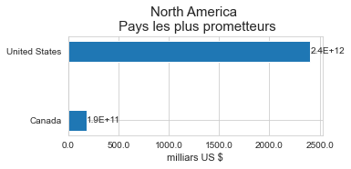

```python
bar1(Serie.tail(3),titre='North America \n Pays les plus prometteurs',size=(5,2),width=.3)
```

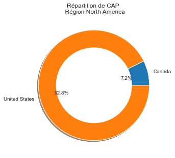

```python
Pie(Serie,titre='Répartition de CAP \n Région North America',part=0)
```

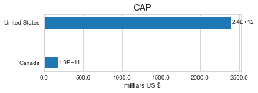

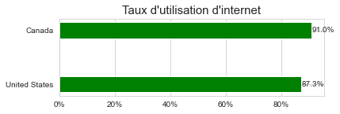

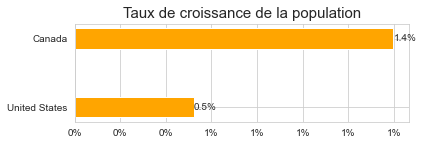

```python
#masque permettant de retenir les noms des n premiers pays du pieplot
mask=DataSet.index.isin(Serie.iloc[-2:].index)
width=.3
# Tracé de CAP
bar1(DataSet[mask].sort_values(by='CAP').iloc[:,0],titre='CAP',size=(6,1.8),width=width)
# Tracé du taux d'utilisation d'internet
bar2(DataSet[mask].sort_values(by='IT.NET.USER.P2').iloc[:,1],titre='Taux d\'utilisation d\'internet',color='green',size=(6,1.8),width=width)
# Tracé du taux de croissance de la population
bar2(DataSet[mask].sort_values(by='SP.POP.GROW').iloc[:,2],titre='Taux de croissance de la population',color='orange',size=(6,1.8),width=width)
```

L'indicateur CAP des USA est 10 fois plus élevé que celui du Canada. Cependant, le taux de croissance démographique des USA est 3 fois moindre que celui du Canada. Par ailleurs, USA et le Canada sont à égalité sur le taux d'utilisation d'internet qui est proche de 90%. Ces deux pays ont donc un potentiel intéresssant pour des raisons distinctes.

## Région East Asia & Pacific

Extraction de la série de pays de la région East Asia & Pacific

```python
Serie=df1.loc['East Asia & Pacific',:].dropna().sort_values(ascending=True)
```

Affichage du top 3 sur l'indicateur CAP

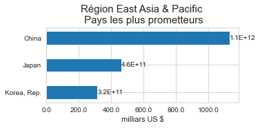

```python
bar1(Serie.tail(3),titre='Région East Asia & Pacific \n Pays les plus prometteurs',size=(5,2))
```

Un outlier : la Chine.  
Le marché Chinois étant trés fermé, il est préférable de l'exclure.

Exclusion de la Chine

```python
S1=Serie.drop('China')
```

Tracé du pieplot

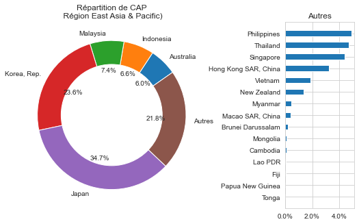

```python
Pie_Autres(S1,titre='Répartition de CAP\n Région East Asia & Pacific)',bar=True,part=5)
```

Regardons en détail les données sur les 3 indicateurs des 7 premiers pays

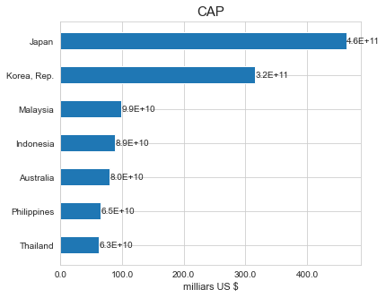

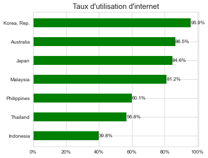

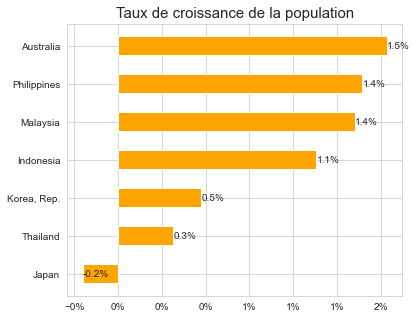

```python
#masque permettant de retenir les noms des n premiers pays du pieplot
mask=DataSet.index.isin(S1.iloc[-7:].index)
# Tracé de CAP
bar1(DataSet[mask].sort_values(by='CAP').iloc[:,0],titre='CAP',size=(6,5))
# Tracé du taux d'utilisation d'internet
bar2(DataSet[mask].sort_values(by='IT.NET.USER.P2').iloc[:,1],titre='Taux d\'utilisation d\'internet',color='green',size=(6,5))
# Tracé du taux de croissance de la population
bar2(DataSet[mask].sort_values(by='SP.POP.GROW').iloc[:,2],titre='Taux de croissance de la population',color='orange',size=(6,5))
```

Japon, Corée du Sud, Malaisie et Australie ont des taux d'utilisation d'internet supérieurs à 80%. Japon a un taux de croissance démographique négatif : de moins en moins de clients potentiels dans le futur.

La Corée du sud a plus de 3 fois la richesse de l'Australie sur la population cible.

Je recommande d'opérer dans ce pays en priorité.